# Biostat 203B Homework 2

Due Feb 8 @ 11:59PM

Jonathan King

```r
knitr::opts_chunk$set(echo = TRUE, cache = TRUE, cache.lazy = FALSE)
# Set root directory to simplify file importing
knitr::opts_knit$set(root.dir = '/mnt/mimiciv/1.0')
library(tidyverse)
library(data.table)
library(lubridate)
```

```r
os <- sessionInfo()$running
if (str_detect(os, "Linux")) {
  mimic_path <- "/mnt/mimiciv/1.0"
} else if (str_detect(os, "macOS")) {
  mimic_path <- "/Users/huazhou/Documents/Box Sync/MIMIC/mimic-iv-1.0"
}
```

In this exercise, we use tidyverse (ggplot2, dplyr, etc) to explore the [MIMIC-IV](https://mimic.mit.edu/docs/iv/) data introduced in [homework 1](https://ucla-biostat-203b.github.io/2022winter/hw/hw1/hw1.html) and to build a cohort of ICU stays.

```r
# tree -s -L 2 /Users/huazhou/Documents/Box\ Sync/MIMIC/mimic-iv-1.0
system(str_c("tree -s -L 2 ", shQuote(mimic_path)), intern = TRUE)
```

```
##  [1] "/mnt/mimiciv/1.0"
##  [2] "├── [       4096]  core"
##  [3] "│   ├── [   17208966]  admissions.csv.gz"
##  [4] "│   ├── [        606]  index.html"
##  [5] "│   ├── [    2955582]  patients.csv.gz"
##  [6] "│   └── [   53014503]  transfers.csv.gz"
##  [7] "├── [       4096]  hosp"
##  [8] "│   ├── [     430049]  d_hcpcs.csv.gz"
##  [9] "│   ├── [   29531152]  diagnoses_icd.csv.gz"
## [10] "│   ├── [     863239]  d_icd_diagnoses.csv.gz"
## [11] "│   ├── [     579998]  d_icd_procedures.csv.gz"
## [12] "│   ├── [      14898]  d_labitems.csv.gz"
## [13] "│   ├── [   11684062]  drgcodes.csv.gz"
## [14] "│   ├── [  515763427]  emar.csv.gz"
## [15] "│   ├── [  476252563]  emar_detail.csv.gz"
```

[output cut: 26 more lines]

## Q1. `read.csv` (base R) vs `read_csv` (tidyverse) vs `fread` (data.table)

There are quite a few utilities in R for reading plain text data files. Let us test the speed of reading a moderate sized compressed csv file, `admissions.csv.gz`, by three programs: `read.csv` in base R, `read_csv` in tidyverse, and `fread` in the popular data.table package.

Which function is fastest? Is there difference in the (default) parsed data types? (Hint: R function `system.time` measures run times.)

For later questions, we stick to the tidyverse.

### Solution

```r
# Compare run times of different file reading functions
system.time(read_1 <- read.csv("./core/admissions.csv.gz"))
```

```
##    user  system elapsed
##  47.858   0.211  48.085
```

```r
system.time(read_2 <- read_csv("./core/admissions.csv.gz"))
```

```
##    user  system elapsed
##   3.702   0.206   2.569
```

```r
system.time(read_3 <- fread("./core/admissions.csv.gz"))
```

```
##    user  system elapsed
##   1.971   0.144   1.151
```

```r
# Check for differences in parsed data types
str(read_1)
```

```
## 'data.frame':    523740 obs. of  15 variables:
##  $ subject_id          : int  14679932 15585972 11989120 17817079 15078341 19124609 17301855 17991012 16865435 13693648 ...
##  $ hadm_id             : int  21038362 24941086 21965160 24709883 23272159 20517215 29732723 24298836 23216961 21640725 ...
##  $ admittime           : Factor w/ 514435 levels "2105-10-04 17:26:00",..: 162283 62357 210124 330971 56261 351331 166789 430755 456181 3345 ...
##  $ dischtime           : Factor w/ 507789 levels "2105-10-12 11:11:00",..: 160158 61694 207314 326516 55632 346651 164592 424886 449948 3316 ...
##  $ deathtime           : Factor w/ 9337 levels "","2110-01-25 09:40:00",..: 1 1 1 1 1 1 1 1 1 1 ...
##  $ admission_type      : Factor w/ 9 levels "AMBULATORY OBSERVATION",..: 4 4 4 4 4 4 4 4 4 4 ...
##  $ admission_location  : Factor w/ 12 levels "","AMBULATORY SURGERY TRANSFER",..: 1 1 1 1 1 1 1 1 1 1 ...
##  $ discharge_location  : Factor w/ 14 levels "","ACUTE HOSPITAL",..: 8 8 8 8 8 8 8 8 8 8 ...
##  $ insurance           : Factor w/ 3 levels "Medicaid","Medicare",..: 3 3 3 3 3 3 3 3 3 3 ...
##  $ language            : Factor w/ 2 levels "?","ENGLISH": 2 2 2 2 2 2 2 2 2 2 ...
##  $ marital_status      : Factor w/ 5 levels "","DIVORCED",..: 4 1 1 1 1 1 1 1 1 1 ...
##  $ ethnicity           : Factor w/ 8 levels "AMERICAN INDIAN/ALASKA NATIVE",..: 7 8 7 5 3 7 8 8 8 8 ...
##  $ edregtime           : Factor w/ 310256 levels "","2109-08-31 02:46:00",..: 1 1 1 1 1 1 1 1 1 1 ...
##  $ edouttime           : Factor w/ 310322 levels "","2109-08-31 07:51:00",..: 1 1 1 1 1 1 1 1 1 1 ...
##  $ hospital_expire_flag: int  0 0 0 0 0 0 0 0 0 0 ...
```

```r
str(read_2)
```

```
## spec_tbl_df [523,740 × 15] (S3: spec_tbl_df/tbl_df/tbl/data.frame)
##  $ subject_id          : num [1:523740] 14679932 15585972 11989120 17817079 15078341 ...
##  $ hadm_id             : num [1:523740] 21038362 24941086 21965160 24709883 23272159 ...
##  $ admittime           : POSIXct[1:523740], format: "2139-09-26 14:16:00" "2123-10-07 23:56:00" ...
##  $ dischtime           : POSIXct[1:523740], format: "2139-09-28 11:30:00" "2123-10-12 11:22:00" ...
##  $ deathtime           : POSIXct[1:523740], format: NA NA ...
##  $ admission_type      : chr [1:523740] "ELECTIVE" "ELECTIVE" "ELECTIVE" "ELECTIVE" ...
##  $ admission_location  : chr [1:523740] NA NA NA NA ...
##  $ discharge_location  : chr [1:523740] "HOME" "HOME" "HOME" "HOME" ...
##  $ insurance           : chr [1:523740] "Other" "Other" "Other" "Other" ...
##  $ language            : chr [1:523740] "ENGLISH" "ENGLISH" "ENGLISH" "ENGLISH" ...
##  $ marital_status      : chr [1:523740] "SINGLE" NA NA NA ...
##  $ ethnicity           : chr [1:523740] "UNKNOWN" "WHITE" "UNKNOWN" "OTHER" ...
##  $ edregtime           : POSIXct[1:523740], format: NA NA ...
##  $ edouttime           : POSIXct[1:523740], format: NA NA ...
##  $ hospital_expire_flag: num [1:523740] 0 0 0 0 0 0 0 0 0 0 ...
##  - attr(*, "spec")=
##   .. cols(
##   ..   subject_id = col_double(),
##   ..   hadm_id = col_double(),
##   ..   admittime = col_datetime(format = ""),
##   ..   dischtime = col_datetime(format = ""),
##   ..   deathtime = col_datetime(format = ""),
##   ..   admission_type = col_character(),
##   ..   admission_location = col_character(),
##   ..   discharge_location = col_character(),
##   ..   insurance = col_character(),
##   ..   language = col_character(),
##   ..   marital_status = col_character(),
##   ..   ethnicity = col_character(),
##   ..   edregtime = col_datetime(format = ""),
##   ..   edouttime = col_datetime(format = ""),
##   ..   hospital_expire_flag = col_double()
##   .. )
##  - attr(*, "problems")=<externalptr>
```

```r
str(read_3)
```

```
## Classes 'data.table' and 'data.frame':   523740 obs. of  15 variables:
##  $ subject_id          : int  14679932 15585972 11989120 17817079 15078341 19124609 17301855 17991012 16865435 13693648 ...
##  $ hadm_id             : int  21038362 24941086 21965160 24709883 23272159 20517215 29732723 24298836 23216961 21640725 ...
##  $ admittime           : POSIXct, format: "2139-09-26 14:16:00" "2123-10-07 23:56:00" ...
##  $ dischtime           : POSIXct, format: "2139-09-28 11:30:00" "2123-10-12 11:22:00" ...
##  $ deathtime           : POSIXct, format: NA NA ...
##  $ admission_type      : chr  "ELECTIVE" "ELECTIVE" "ELECTIVE" "ELECTIVE" ...
##  $ admission_location  : chr  "" "" "" "" ...
##  $ discharge_location  : chr  "HOME" "HOME" "HOME" "HOME" ...
##  $ insurance           : chr  "Other" "Other" "Other" "Other" ...
##  $ language            : chr  "ENGLISH" "ENGLISH" "ENGLISH" "ENGLISH" ...
##  $ marital_status      : chr  "SINGLE" "" "" "" ...
##  $ ethnicity           : chr  "UNKNOWN" "WHITE" "UNKNOWN" "OTHER" ...
##  $ edregtime           : POSIXct, format: NA NA ...
##  $ edouttime           : POSIXct, format: NA NA ...
##  $ hospital_expire_flag: int  0 0 0 0 0 0 0 0 0 0 ...
##  - attr(*, ".internal.selfref")=<externalptr>
```

```r
# Delete temporary reads
rm(read_1, read_2, read_3)
```

- `fread` is the fastest function overall, with it and ‘read_csv’ both being much faster than `read.csv`. By default, `read.csv` parsed all character variables and dates as factors, while both `read_csv` and `fread` correctly parsed character variables and parsed dates as POSIXct variables. Also, `read_csv` parsed id numbers as numeric, while the other two file reading functions parsed the id numbers as integers.

## Q2. ICU stays

`icustays.csv.gz` (https://mimic.mit.edu/docs/iv/modules/icu/icustays/) contains data about Intensive Care Units (ICU) stays. The first 10 lines are

```r
system(
  str_c(
    "zcat < ",
    shQuote(str_c(mimic_path, "/icu/icustays.csv.gz")),
    " | head"
    ),
  intern = TRUE
)
```

```
##  [1] "subject_id,hadm_id,stay_id,first_careunit,last_careunit,intime,outtime,los"
##  [2] "17867402,24528534,31793211,Trauma SICU (TSICU),Trauma SICU (TSICU),2154-03-03 04:11:00,2154-03-04 18:16:56,1.5874537037037035"
##  [3] "14435996,28960964,31983544,Trauma SICU (TSICU),Trauma SICU (TSICU),2150-06-19 17:57:00,2150-06-22 18:33:54,3.025625"
##  [4] "17609946,27385897,33183475,Trauma SICU (TSICU),Trauma SICU (TSICU),2138-02-05 18:54:00,2138-02-15 12:42:05,9.741724537037038"
##  [5] "18966770,23483021,34131444,Trauma SICU (TSICU),Trauma SICU (TSICU),2123-10-25 10:35:00,2123-10-25 18:59:47,0.35054398148148147"
##  [6] "12776735,20817525,34547665,Neuro Stepdown,Neuro Stepdown,2200-07-12 00:33:00,2200-07-13 16:44:40,1.6747685185185184"
##  [7] "10215159,24283593,34569476,Trauma SICU (TSICU),Trauma SICU (TSICU),2124-09-20 15:05:29,2124-09-21 22:06:58,1.2926967592592593"
##  [8] "14489052,26516390,35056286,Trauma SICU (TSICU),Trauma SICU (TSICU),2118-10-26 10:33:56,2118-10-26 20:28:10,0.4126620370370371"
##  [9] "15914763,28906020,36909804,Trauma SICU (TSICU),Trauma SICU (TSICU),2176-12-14 12:00:00,2176-12-17 11:47:01,2.9909837962962964"
## [10] "16256226,20013290,39289362,Neuro Stepdown,Neuro Stepdown,2150-12-20 16:09:08,2150-12-21 14:58:40,0.9510648148148149"
```

1. Import `icustays.csv.gz` as a tibble `icustays_tble`.

### Solution

```r
icustays_tble <- read_csv("./icu/icustays.csv.gz") %>%
  print(width = Inf)
```

```
## # A tibble: 76,540 × 8
##    subject_id  hadm_id  stay_id first_careunit
##         <dbl>    <dbl>    <dbl> <chr>
##  1   17867402 24528534 31793211 Trauma SICU (TSICU)
##  2   14435996 28960964 31983544 Trauma SICU (TSICU)
##  3   17609946 27385897 33183475 Trauma SICU (TSICU)
##  4   18966770 23483021 34131444 Trauma SICU (TSICU)
##  5   12776735 20817525 34547665 Neuro Stepdown
##  6   10215159 24283593 34569476 Trauma SICU (TSICU)
##  7   14489052 26516390 35056286 Trauma SICU (TSICU)
##  8   15914763 28906020 36909804 Trauma SICU (TSICU)
##  9   16256226 20013290 39289362 Neuro Stepdown
## 10   19194449 21641999 39387567 Coronary Care Unit (CCU)
##    last_careunit            intime              outtime               los
##    <chr>                    <dttm>              <dttm>              <dbl>
##  1 Trauma SICU (TSICU)      2154-03-03 04:11:00 2154-03-04 18:16:56 1.59
##  2 Trauma SICU (TSICU)      2150-06-19 17:57:00 2150-06-22 18:33:54 3.03
##  3 Trauma SICU (TSICU)      2138-02-05 18:54:00 2138-02-15 12:42:05 9.74
##  4 Trauma SICU (TSICU)      2123-10-25 10:35:00 2123-10-25 18:59:47 0.351
##  5 Neuro Stepdown           2200-07-12 00:33:00 2200-07-13 16:44:40 1.67
##  6 Trauma SICU (TSICU)      2124-09-20 15:05:29 2124-09-21 22:06:58 1.29
##  7 Trauma SICU (TSICU)      2118-10-26 10:33:56 2118-10-26 20:28:10 0.413
##  8 Trauma SICU (TSICU)      2176-12-14 12:00:00 2176-12-17 11:47:01 2.99
##  9 Neuro Stepdown           2150-12-20 16:09:08 2150-12-21 14:58:40 0.951
## 10 Coronary Care Unit (CCU) 2123-11-12 02:53:35 2123-11-12 13:52:03 0.457
## # … with 76,530 more rows
```

2. How many unique `subject_id`? Can a `subject_id` have multiple ICU stays?

### Solution

```r
icustays_tble %>%
  group_by(subject_id) %>%
  summarise(number_of_stays = n_distinct(stay_id)) %>%
  arrange(desc(number_of_stays))
```

```
## # A tibble: 53,150 × 2
##    subject_id number_of_stays
##         <dbl>           <int>
##  1   18358138              37
##  2   12468016              33
##  3   17585185              33
##  4   13269859              30
##  5   18676703              26
##  6   11281568              25
##  7   15455517              25
##  8   15573773              24
##  9   17937834              24
## 10   15131736              22
## # … with 53,140 more rows
```

- There are 53,150 unique `subject_id`, and each one can have multiple ICU stays.
3. For each `subject_id`, let’s only keep the first ICU stay in the tibble `icustays_tble`.

### Solution

```r
icustays_tble <- icustays_tble %>%
  group_by(subject_id) %>%
  arrange(intime) %>%
  distinct(subject_id, .keep_all = TRUE) %>%
  print(width = Inf)
```

```
## # A tibble: 53,150 × 8
## # Groups:   subject_id [53,150]
##    subject_id  hadm_id  stay_id first_careunit
##         <dbl>    <dbl>    <dbl> <chr>
##  1   18106347 24305596 30588857 Cardiac Vascular Intensive Care Unit (CVICU)
##  2   17195991 23542772 38319097 Surgical Intensive Care Unit (SICU)
##  3   16284044 23864737 36817845 Cardiac Vascular Intensive Care Unit (CVICU)
##  4   18122666 23883987 39753527 Medical/Surgical Intensive Care Unit (MICU/SICU)
##  5   18780420 28977824 32140208 Neuro Surgical Intensive Care Unit (Neuro SICU)
##  6   15092543 28768907 38339174 Neuro Intermediate
##  7   13201095 28453791 39953418 Coronary Care Unit (CCU)
##  8   12770182 20446666 34901199 Medical Intensive Care Unit (MICU)
##  9   12224263 23294937 37546608 Trauma SICU (TSICU)
## 10   19564586 22461053 37310703 Coronary Care Unit (CCU)
##    last_careunit                                    intime
```

[output cut: 24 more lines]

## Q3. `admission` data

Information of the patients admitted into hospital is available in `admissions.csv.gz`. See https://mimic.mit.edu/docs/iv/modules/core/admissions/ for details of each field in this file. The first 10 lines are

```r
system(
  str_c(
    "zcat < ",
    shQuote(str_c(mimic_path, "/core/admissions.csv.gz")),
    " | head"
    ),
  intern = TRUE
)
```

```
##  [1] "subject_id,hadm_id,admittime,dischtime,deathtime,admission_type,admission_location,discharge_location,insurance,language,marital_status,ethnicity,edregtime,edouttime,hospital_expire_flag"
##  [2] "14679932,21038362,2139-09-26 14:16:00,2139-09-28 11:30:00,,ELECTIVE,,HOME,Other,ENGLISH,SINGLE,UNKNOWN,,,0"
##  [3] "15585972,24941086,2123-10-07 23:56:00,2123-10-12 11:22:00,,ELECTIVE,,HOME,Other,ENGLISH,,WHITE,,,0"
##  [4] "11989120,21965160,2147-01-14 09:00:00,2147-01-17 14:25:00,,ELECTIVE,,HOME,Other,ENGLISH,,UNKNOWN,,,0"
##  [5] "17817079,24709883,2165-12-27 17:33:00,2165-12-31 21:18:00,,ELECTIVE,,HOME,Other,ENGLISH,,OTHER,,,0"
##  [6] "15078341,23272159,2122-08-28 08:48:00,2122-08-30 12:32:00,,ELECTIVE,,HOME,Other,ENGLISH,,BLACK/AFRICAN AMERICAN,,,0"
##  [7] "19124609,20517215,2169-03-14 12:44:00,2169-03-20 19:15:00,,ELECTIVE,,HOME,Other,ENGLISH,,UNKNOWN,,,0"
##  [8] "17301855,29732723,2140-06-06 14:23:00,2140-06-08 14:25:00,,ELECTIVE,,HOME,Other,ENGLISH,,WHITE,,,0"
##  [9] "17991012,24298836,2181-07-10 20:28:00,2181-07-12 15:49:00,,ELECTIVE,,HOME,Other,ENGLISH,,WHITE,,,0"
## [10] "16865435,23216961,2185-07-19 02:12:00,2185-07-21 11:50:00,,ELECTIVE,,HOME,Other,ENGLISH,,WHITE,,,0"
```

1. Import `admissions.csv.gz` as a tibble `admissions_tble`.

### Solution

```r
admissions_tble <- read_csv("./core/admissions.csv.gz") %>%
  print(width = Inf)
```

```
## # A tibble: 523,740 × 15
##    subject_id  hadm_id admittime           dischtime
##         <dbl>    <dbl> <dttm>              <dttm>
##  1   14679932 21038362 2139-09-26 14:16:00 2139-09-28 11:30:00
##  2   15585972 24941086 2123-10-07 23:56:00 2123-10-12 11:22:00
##  3   11989120 21965160 2147-01-14 09:00:00 2147-01-17 14:25:00
##  4   17817079 24709883 2165-12-27 17:33:00 2165-12-31 21:18:00
##  5   15078341 23272159 2122-08-28 08:48:00 2122-08-30 12:32:00
##  6   19124609 20517215 2169-03-14 12:44:00 2169-03-20 19:15:00
##  7   17301855 29732723 2140-06-06 14:23:00 2140-06-08 14:25:00
##  8   17991012 24298836 2181-07-10 20:28:00 2181-07-12 15:49:00
##  9   16865435 23216961 2185-07-19 02:12:00 2185-07-21 11:50:00
## 10   13693648 21640725 2111-01-30 23:43:00 2111-02-02 13:03:00
##    deathtime admission_type admission_location discharge_location
##    <dttm>    <chr>          <chr>              <chr>
```

[output cut: 35 more lines]

2. Let’s only keep the admissions that have a match in `icustays_tble` according to `subject_id` and `hadmi_id`.

### Solution

```r
admissions_tble <- admissions_tble %>%
  semi_join(icustays_tble, by = c("subject_id", "hadm_id")) %>%
  print(width = Inf)
```

```
## # A tibble: 53,150 × 15
##    subject_id  hadm_id admittime           dischtime
##         <dbl>    <dbl> <dttm>              <dttm>
##  1   10222255 28200985 2120-11-20 20:25:00 2120-11-22 13:00:00
##  2   14485852 28712010 2113-10-31 00:23:00 2113-11-04 16:50:00
##  3   18709254 23758948 2195-10-12 01:31:00 2195-10-12 13:51:00
##  4   16837807 23526268 2151-03-19 06:09:00 2151-03-19 07:20:00
##  5   17642680 27734285 2116-05-29 12:48:00 2116-05-30 12:31:00
##  6   18230965 21251728 2142-03-12 20:00:00 2142-03-17 15:26:00
##  7   17374121 27667114 2115-07-22 07:15:00 2115-07-24 17:50:00
##  8   13346506 28533404 2181-11-19 14:32:00 2181-11-22 18:47:00
##  9   18030332 24679656 2152-07-22 21:28:00 2152-07-27 16:49:00
## 10   14328744 29576470 2126-08-20 09:26:00 2126-08-21 11:36:00
##    deathtime           admission_type     admission_location
##    <dttm>              <chr>              <chr>
```

[output cut: 35 more lines]

3. Summarize the following variables by graphics.
- admission year
- admission month
- admission month day
- admission week day
- admission hour (anything unusual?)

### Solution

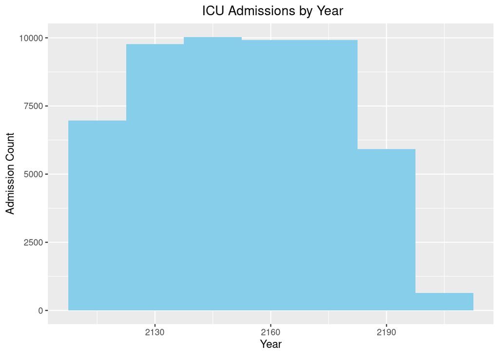

```r
# Summarize by admission year
admissions_tble %>%
  mutate(year = year(admittime)) %>%
  ggplot() +
  geom_histogram(mapping = aes(x = year), fill = "skyblue", binwidth = 15) +
  labs(title = " ICU Admissions by Year", x = "Year", y = "Admission Count") +
  theme(plot.title = element_text(hjust = 0.5))
```

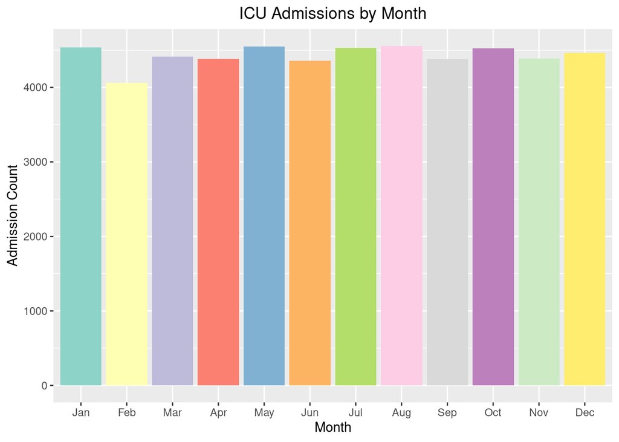

```r
# Summarize by admission month
admissions_tble %>%
  mutate(month = month(admittime, label = TRUE)) %>%
  ggplot() +
  geom_bar(mapping = aes(x = month, fill = month)) +
  scale_fill_brewer(palette = "Set3") +
  theme(legend.position = "none") +
  labs(title = "ICU Admissions by Month", x = "Month", y = "Admission Count") +
  theme(plot.title = element_text(hjust = 0.5))
```

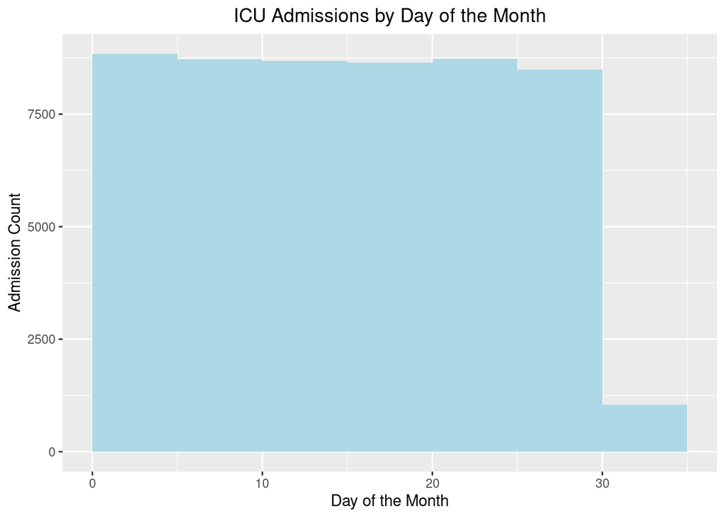

```r
# Summarize by day of the month
admissions_tble %>%
  mutate(mday = mday(admittime)) %>%
  ggplot() +
  geom_histogram(
    mapping = aes(x = mday),
    fill = "lightblue",
    binwidth = 5,
    center = 2.5
  ) +
  labs(
    title = "ICU Admissions by Day of the Month",
    x = "Day of the Month",
    y = "Admission Count"
  ) +
  theme(plot.title = element_text(hjust = 0.5))
```

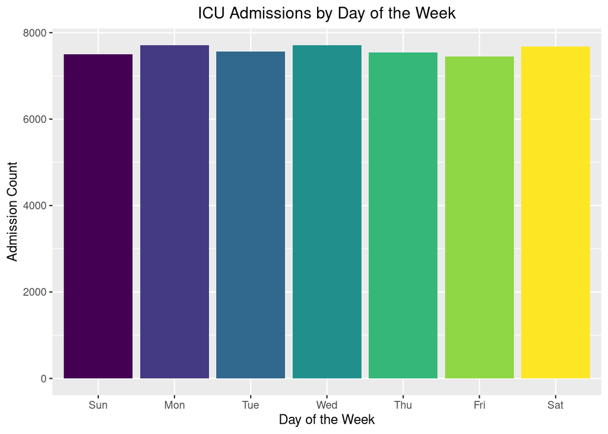

```r
# Summarize by day of the week
admissions_tble %>%
  mutate(wday = wday(admittime, label = TRUE)) %>%
  ggplot() +
  geom_bar(mapping = aes(x = wday, fill = wday)) +
  theme(legend.position = "none") +
  labs(
    title = "ICU Admissions by Day of the Week",
    x = "Day of the Week",
    y = "Admission Count"
  ) +
  theme(plot.title = element_text(hjust = 0.5))
```

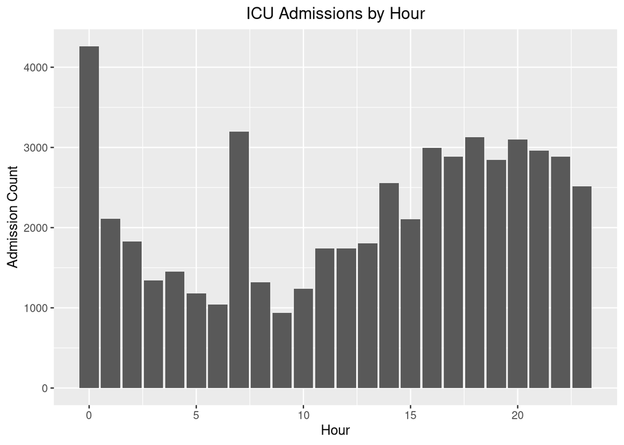

```r
# Summarize by admission hour
admissions_tble %>%
  mutate(hour = hour(admittime)) %>%
  ggplot() +
  geom_bar(mapping = aes(x = hour)) +
  theme(legend.position = "none") +
  labs(title = "ICU Admissions by Hour", x = "Hour", y = "Admission Count") +
  theme(plot.title = element_text(hjust = 0.5))
```

- The 12 a.m. hour was when the most patients were admitted. Fewer patients are admitted in the morning hours after, except for an unusual spike in the 7 a.m. hour.

## Q4. `patients` data

Patient information is available in `patients.csv.gz`. See https://mimic.mit.edu/docs/iv/modules/core/patients/ for details of each field in this file. The first 10 lines are

```r
system(
  str_c(
    "zcat < ",
    shQuote(str_c(mimic_path, "/core/patients.csv.gz")),
    " | head"
    ),
  intern = TRUE
)
```

```
##  [1] "subject_id,gender,anchor_age,anchor_year,anchor_year_group,dod"
##  [2] "10000048,F,23,2126,2008 - 2010,"
##  [3] "10002723,F,0,2128,2017 - 2019,"
##  [4] "10003939,M,0,2184,2008 - 2010,"
##  [5] "10004222,M,0,2161,2014 - 2016,"
##  [6] "10005325,F,0,2154,2011 - 2013,"
##  [7] "10007338,F,0,2153,2017 - 2019,"
##  [8] "10008101,M,0,2142,2008 - 2010,"
##  [9] "10009872,F,0,2168,2014 - 2016,"
## [10] "10011333,F,0,2132,2014 - 2016,"
```

1. Import `patients.csv.gz` (https://mimic.mit.edu/docs/iv/modules/core/patients/) as a tibble `patients_tble` and only keep the patients who have a match in `icustays_tble` (according to `subject_id`).

### Solution

```r
patients_tble <- read_csv("./core/patients.csv.gz") %>%
  semi_join(icustays_tble) %>%
  print(width = Inf)
```

```
## # A tibble: 53,150 × 6
##    subject_id gender anchor_age anchor_year anchor_year_group dod
##         <dbl> <chr>       <dbl>       <dbl> <chr>             <date>
##  1   10018928 F              31        2125 2008 - 2010       NA
##  2   10076543 F              78        2187 2008 - 2010       NA
##  3   10098428 F              85        2119 2008 - 2010       NA
##  4   10127185 M              60        2141 2008 - 2010       NA
##  5   10148710 M              67        2137 2008 - 2010       NA
##  6   10156486 F              75        2124 2017 - 2019       NA
##  7   10159585 M              59        2146 2008 - 2010       2154-04-16
##  8   10171525 F              27        2115 2014 - 2016       NA
##  9   10196360 M              57        2118 2011 - 2013       NA
## 10   10227823 M              45        2156 2014 - 2016       NA
## # … with 53,140 more rows
```

2. Summarize variables `gender` and `anchor_age`, and explain any patterns you see.

### Solution

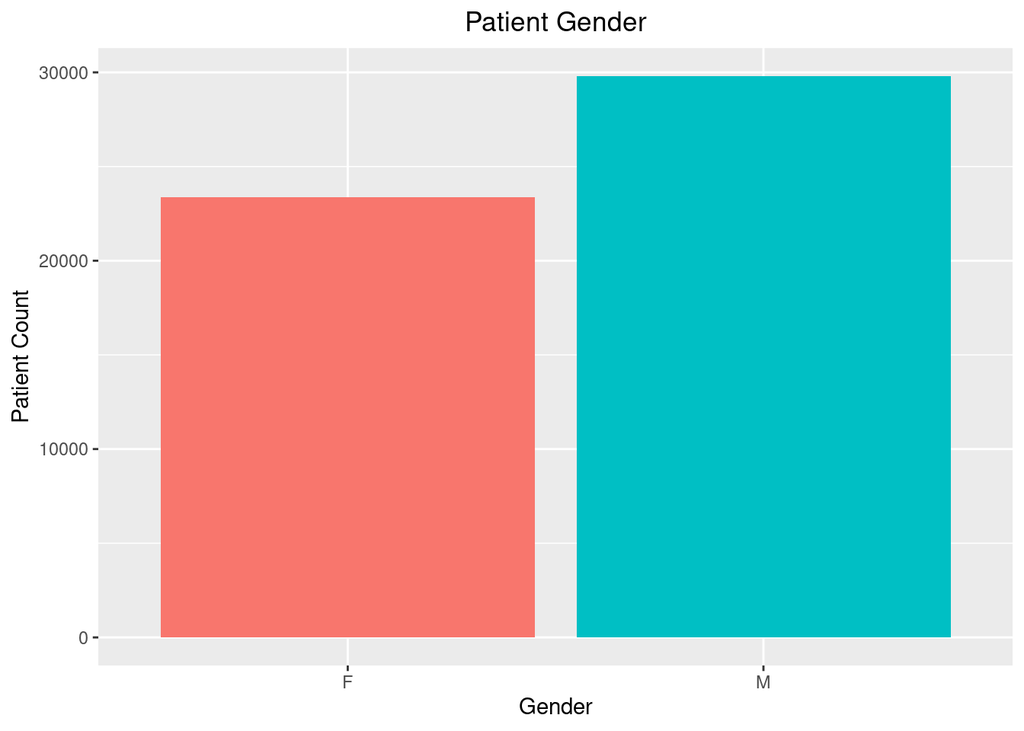

```r
# Make barplot of gender
ggplot(data = patients_tble) +
  geom_bar(aes(x = gender, fill = gender)) +
  theme(legend.position = "none") +
  labs(title = "Patient Gender", x = "Gender", y = "Patient Count") +
  theme(plot.title = element_text(hjust = 0.5))
```

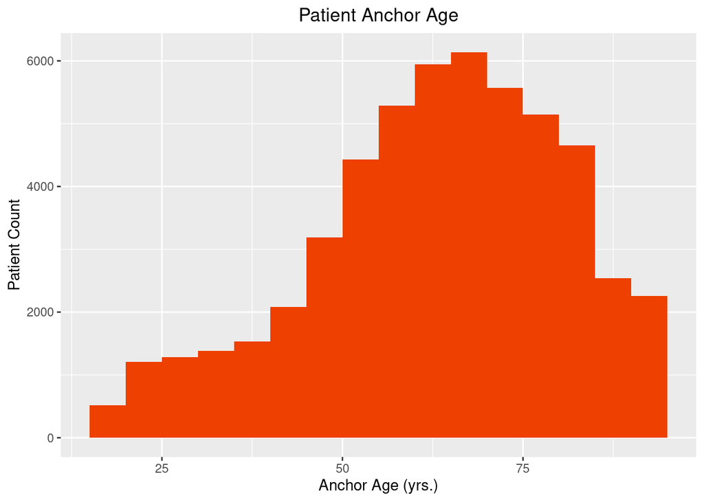

```r
# Create histogram of patient anchor age
ggplot(data = patients_tble) +
  geom_histogram(
    aes(x = anchor_age),
    fill = "orangered2",
    binwidth = 5,
    center = 17.5
  ) +
  labs(
    title = "Patient Anchor Age",
    x = "Anchor Age (yrs.)",
    y = "Patient Count"
  ) +
  theme(plot.title = element_text(hjust = 0.5))
```

```r
# Generate numeric summary of anchor_age by gender
patients_tble %>%
  group_by(gender) %>%
  summarise(
    n = n(),
    mean_anchor_age = mean(anchor_age),
    median_anchor_age = median(anchor_age),
    sd_anchor_age = sd(anchor_age),
    min_anchor_age = min(anchor_age),
    max_anchor_age = max(anchor_age)
  ) %>%
  print(width = Inf)
```

```
## # A tibble: 2 × 7
##   gender     n mean_anchor_age median_anchor_age sd_anchor_age min_anchor_age
##   <chr>  <int>           <dbl>             <dbl>         <dbl>          <dbl>
## 1 F      23353            64.8                67          17.9             18
## 2 M      29797            62.5                64          16.6             18
##   max_anchor_age
##            <dbl>
## 1             91
## 2             91
```

- Most patients were male and had an anchor age above 60, with the highest number of patients having an anchor age between 65 and 70 compared to any other five-year age range. Mean and median anchor age were lower for male patients compared to female patients. Standard deviation in anchor age was also lower for male patients. Minimum patient anchor age was 18 years, and maximum patient anchor age was 91 years for both genders.

## Q5. Lab results

`labevents.csv.gz` (https://mimic.mit.edu/docs/iv/modules/hosp/labevents/) contains all laboratory measurements for patients. The first 10 lines are

```r
system(
  str_c(
    "zcat < ",
    shQuote(str_c(mimic_path, "/hosp/labevents.csv.gz")),
    " | head"
    ),
  intern = TRUE
)
```

```
##  [1] "labevent_id,subject_id,hadm_id,specimen_id,itemid,charttime,storetime,value,valuenum,valueuom,ref_range_lower,ref_range_upper,flag,priority,comments"
##  [2] "670,10000048,,6448755,51484,2126-11-22 19:20:00,2126-11-22 20:07:00,150,150,mg/dL,,,,STAT,"
##  [3] "673,10000048,,6448755,51491,2126-11-22 19:20:00,2126-11-22 20:07:00,6.5,6.5,units,5,8,,STAT,"
##  [4] "675,10000048,,6448755,51498,2126-11-22 19:20:00,2126-11-22 20:07:00,1.029,1.029, ,1.001,1.035,,STAT,"
##  [5] "683,10000048,,82729055,50861,2126-11-22 20:45:00,2126-11-23 00:55:00,39,39,IU/L,0,40,,STAT,"
##  [6] "684,10000048,,82729055,50862,2126-11-22 20:45:00,2126-11-23 00:55:00,4.7,4.7,g/dL,3.4,4.8,,STAT,"
##  [7] "685,10000048,,82729055,50863,2126-11-22 20:45:00,2126-11-23 00:55:00,45,45,IU/L,39,117,,STAT,"
##  [8] "686,10000048,,82729055,50868,2126-11-22 20:45:00,2126-11-22 21:32:00,13,13,mEq/L,8,20,,STAT,"
##  [9] "687,10000048,,82729055,50878,2126-11-22 20:45:00,2126-11-23 00:55:00,28,28,IU/L,0,40,,STAT,"
## [10] "688,10000048,,82729055,50882,2126-11-22 20:45:00,2126-11-22 21:32:00,26,26,mEq/L,22,32,,STAT,"
```

`d_labitems.csv.gz` is the dictionary of lab measurements.

```r
system(
  str_c(
    "zcat < ",
    shQuote(str_c(mimic_path, "/hosp/d_labitems.csv.gz")),
    " | head"
    ),
  intern = TRUE
)
```

```
##  [1] "itemid,label,fluid,category,loinc_code"
##  [2] "51905, ,Other Body Fluid,Chemistry,"
##  [3] "51532,11-Deoxycorticosterone,Blood,Chemistry,"
##  [4] "51957,17-Hydroxycorticosteroids,Urine,Chemistry,"
##  [5] "51958,\"17-Ketosteroids, Urine\",Urine,Chemistry,"
##  [6] "52068,24 Hr,Blood,Hematology,"
##  [7] "51066,24 hr Calcium,Urine,Chemistry,"
##  [8] "51067,24 hr Creatinine,Urine,Chemistry,"
##  [9] "51068,24 hr Protein,Urine,Chemistry,"
## [10] "50853,25-OH Vitamin D,Blood,Chemistry,"
```

1. Find how many rows are in `labevents.csv.gz`.

### Solution

```bash
zcat /mnt/mimiciv/1.0/hosp/labevents.csv.gz | tail -n+2 | wc -l
```

```
## 122103667
```

2. We are interested in the lab measurements of creatinine (50912), potassium (50971), sodium (50983), chloride (50902), bicarbonate (50882), hematocrit (51221), white blood cell count (51301), glucose (50931), magnesium (50960), and calcium (50893). Retrieve a subset of `labevents.csv.gz` only containing these items for the patients in `icustays_tble` as a tibble `labevents_tble`.

   Hint: `labevents.csv.gz` is a data file too big to be read in by the `read_csv` function in its default setting. Utilize the `col_select` and `lazy` options in the `read_csv` function to reduce the memory burden.

### Solution

```r
labevents_tble <- read_csv("./hosp/labevents_filtered_itemid.csv.gz") %>%
  semi_join(icustays_tble) %>%
  print()
```

```
## # A tibble: 16,698,462 × 4
##    subject_id itemid charttime           valuenum
##         <dbl>  <dbl> <dttm>                 <dbl>
##  1   10003700  50882 2162-11-15 17:00:00     27
##  2   10003700  50902 2162-11-15 17:00:00    103
##  3   10003700  50912 2162-11-15 17:00:00      1
##  4   10003700  50931 2162-11-15 17:00:00     93
##  5   10003700  50971 2162-11-15 17:00:00      4.1
##  6   10003700  50983 2162-11-15 17:00:00    141
##  7   10003700  51221 2162-11-15 17:00:00     40
##  8   10003700  51301 2162-11-15 17:00:00      6.7
##  9   10003700  51221 2165-04-24 03:40:00     41
## 10   10003700  51301 2165-04-24 03:40:00      5.8
## # … with 16,698,452 more rows
```

```r
# Read in dictionary of lab measurements
labevents_dict <- read_csv("./hosp/d_labitems.csv.gz")
```

3. Further restrict `labevents_tble` to the first lab measurement during the ICU stay.

### Solution

```r
# Create table to determine first lab measurement
chartime <- select(icustays_tble, subject_id, intime, outtime)
# Find first measurement after check-in and restrict lab events
labevents_tble <- left_join(labevents_tble, chartime) %>%
  arrange(subject_id) %>%
  filter(charttime >= intime) %>%
  filter(charttime <= outtime) %>%
  distinct(subject_id, itemid, .keep_all = TRUE) %>%
# Create separate columns for each lab measurement and use measurement names
  inner_join(labevents_dict, by = "itemid") %>%
  select(subject_id, label, valuenum) %>%
  pivot_wider(names_from = label, values_from = valuenum) %>%
  print(width = Inf)
```

```
## # A tibble: 51,623 × 11
##    subject_id Bicarbonate `Calcium, Total` Chloride Creatinine Magnesium
##         <dbl>       <dbl>            <dbl>    <dbl>      <dbl>     <dbl>
##  1   10000032          21              9.3      102        0.5       2.3
##  2   10001217          23              8.2      104        0.4       1.9
##  3   10001725          24              9.1      106        0.8       1.5
##  4   10001884          33              9.8       96        1.1       2.2
##  5   10002013          23             NA        109        1.1       2.1
##  6   10002155          25              8.8      106        0.9       2
##  7   10002223          26              8.7      102        0.8       2
##  8   10002348          23              9.4      107        0.8       1.6
##  9   10002428          20              7.4       98        0.8       1.4
## 10   10002430          22              9.2      105        2.2       2.3
##    Potassium Sodium Glucose Hematocrit `White Blood Cells`
##        <dbl>  <dbl>   <dbl>      <dbl>               <dbl>
##  1       4.7    132     115       NA                  NA
##  2       3.6    138     113       33.6                19
##  3       3.9    140     146       39.1                17
##  4       4      136     145       36                  18.4
##  5       4      140      98       28.6                18.2
##  6       4.5    139      95       37.9                 5.5
##  7       3.9    138      88       32.5                10.1
##  8       4.8    142      99       39.3                 4.3
##  9       3.9    129      72       28.7                22.4
## 10       3.8    144     135       36.6                10.3
## # … with 51,613 more rows
```

4. Summarize the lab measurements by appropriate numerics and graphics.

### Solution

```r
# Calculate summary statistics for all lab measurements
labevents_tble %>%
  select(-subject_id) %>%
  summarize_all(
    list(
      n_valid = ~ sum(!is.na(.)),
      mean = mean,
      sd = sd,
      median = median,
      min = min,
      max = max
    ),
    na.rm = TRUE
  ) %>%
  print(width = Inf)
```

```
## # A tibble: 1 × 60
##   Bicarbonate_n_valid `Calcium, Total_n_valid` Chloride_n_valid
##                 <int>                    <int>            <int>
## 1               52438                    51308            52456
##   Creatinine_n_valid Magnesium_n_valid Potassium_n_valid Sodium_n_valid
##                <int>             <int>             <int>          <int>
## 1              52469             52293             52455          52458
##   Hematocrit_n_valid `White Blood Cells_n_valid` Glucose_n_valid
##                <int>                       <int>           <int>
## 1              52449                       52428           52328
##   Bicarbonate_mean `Calcium, Total_mean` Chloride_mean Creatinine_mean
##              <dbl>                 <dbl>         <dbl>           <dbl>
## 1             23.2                  8.38          104.            1.30
##   Magnesium_mean Potassium_mean Sodium_mean Hematocrit_mean
##            <dbl>          <dbl>       <dbl>           <dbl>
## 1           2.00           4.14        139.            32.9
##   `White Blood Cells_mean` Glucose_mean Bicarbonate_sd `Calcium, Total_sd`
##                      <dbl>        <dbl>          <dbl>               <dbl>
## 1                     12.0         147.           4.05               0.808
##   Chloride_sd Creatinine_sd Magnesium_sd Potassium_sd Sodium_sd Hematocrit_sd
##         <dbl>         <dbl>        <dbl>        <dbl>     <dbl>         <dbl>
## 1        6.03          1.43        0.417        0.595      4.32          6.38
##   `White Blood Cells_sd` Glucose_sd Bicarbonate_median `Calcium, Total_median`
##                    <dbl>      <dbl>              <dbl>                   <dbl>
## 1                   9.78       149.                 23                     8.4
##   Chloride_median Creatinine_median Magnesium_median Potassium_median
##             <dbl>             <dbl>            <dbl>            <dbl>
## 1             105               0.9                2              4.1
##   Sodium_median Hematocrit_median `White Blood Cells_median` Glucose_median
##           <dbl>             <dbl>                      <dbl>          <dbl>
## 1           139              32.8                       10.5            114
##   Bicarbonate_min `Calcium, Total_min` Chloride_min Creatinine_min Magnesium_min
##             <dbl>                <dbl>        <dbl>          <dbl>         <dbl>
## 1               3                  1.8           77              0           0.6
##   Potassium_min Sodium_min Hematocrit_min `White Blood Cells_min` Glucose_min
##           <dbl>      <dbl>          <dbl>                   <dbl>       <dbl>
## 1           1.6         97           10.9                     0.1           1
##   Bicarbonate_max `Calcium, Total_max` Chloride_max Creatinine_max Magnesium_max
##             <dbl>                <dbl>        <dbl>          <dbl>         <dbl>
## 1              46                   43          140           33.1           9.2
##   Potassium_max Sodium_max Hematocrit_max `White Blood Cells_max` Glucose_max
##           <dbl>      <dbl>          <dbl>                   <dbl>       <dbl>
## 1           9.9        176           67.7                    472.        5840
```

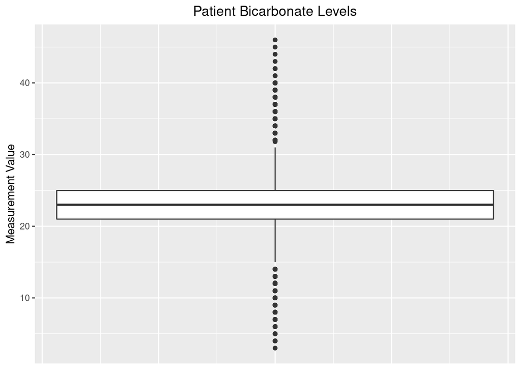

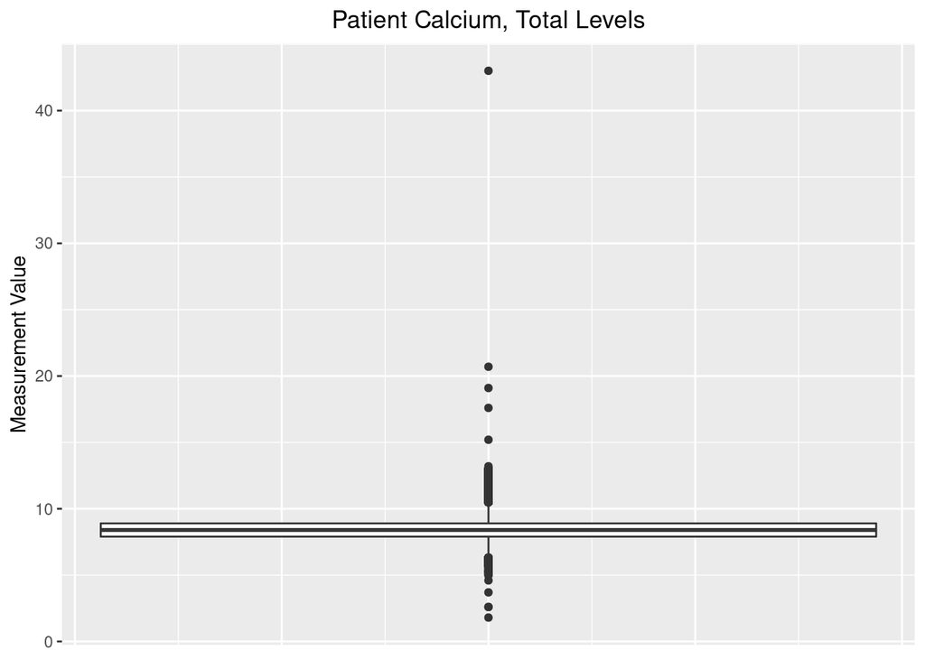

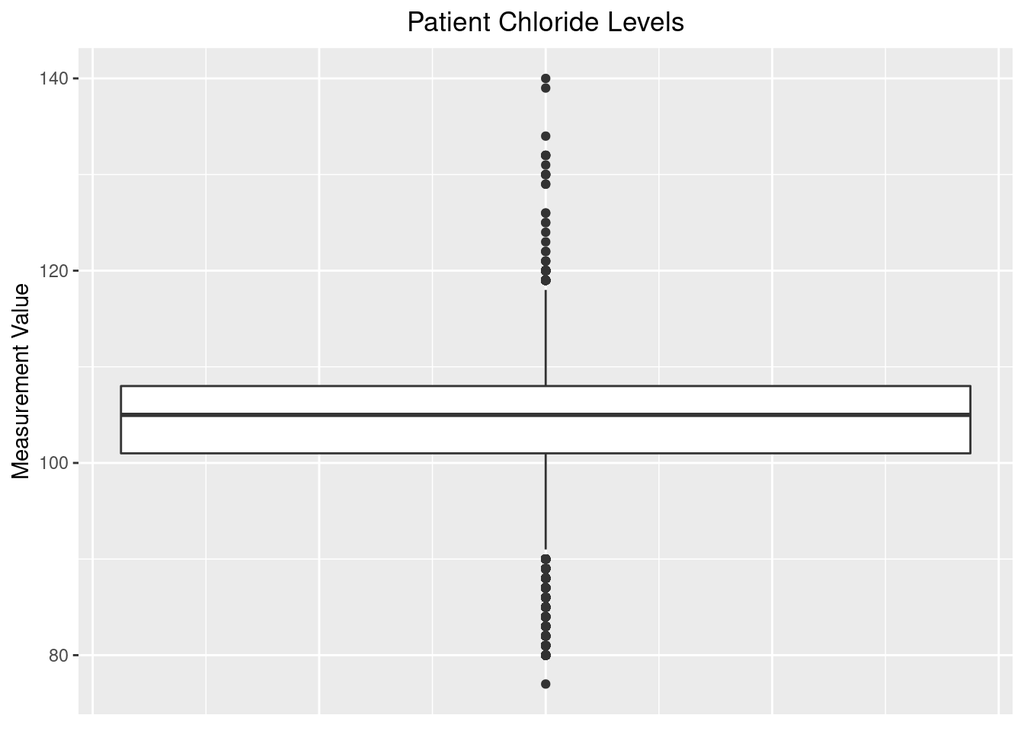

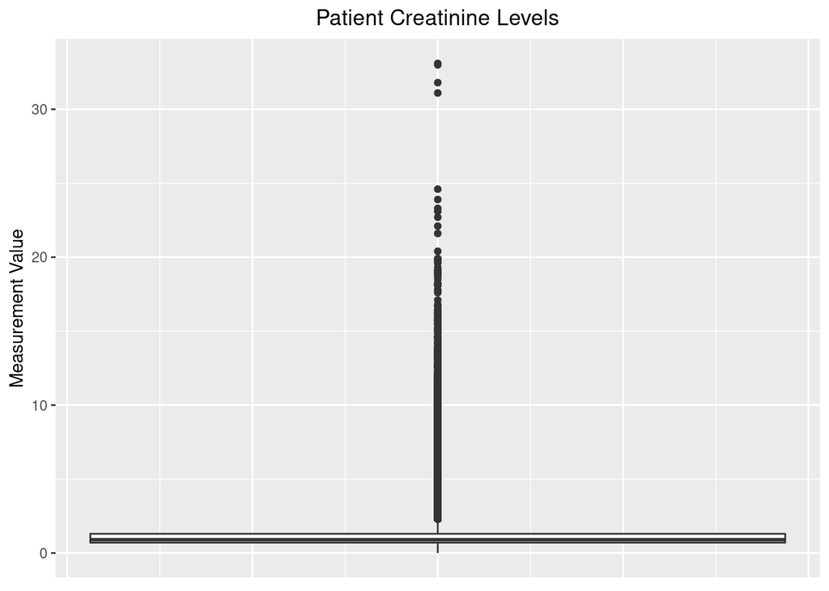

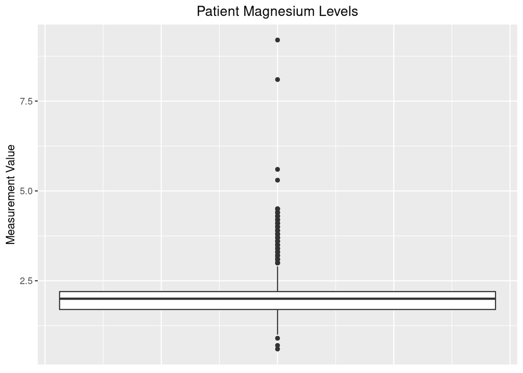

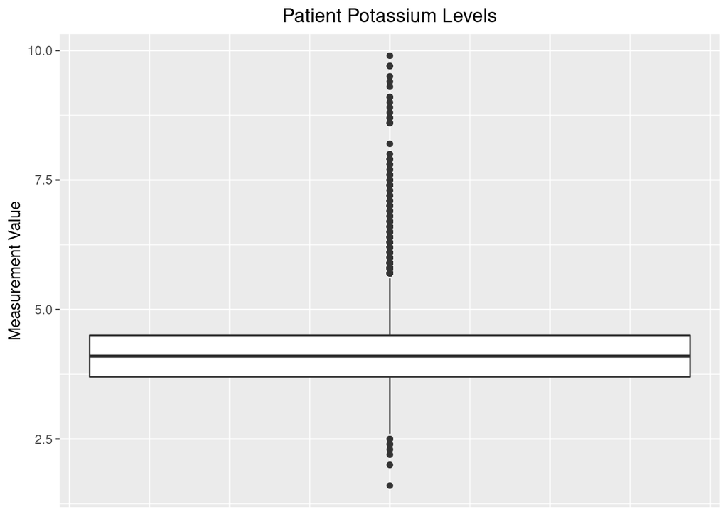

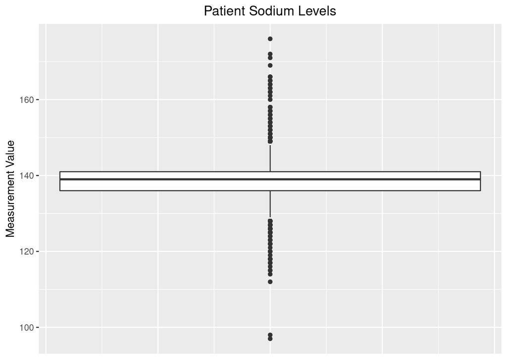

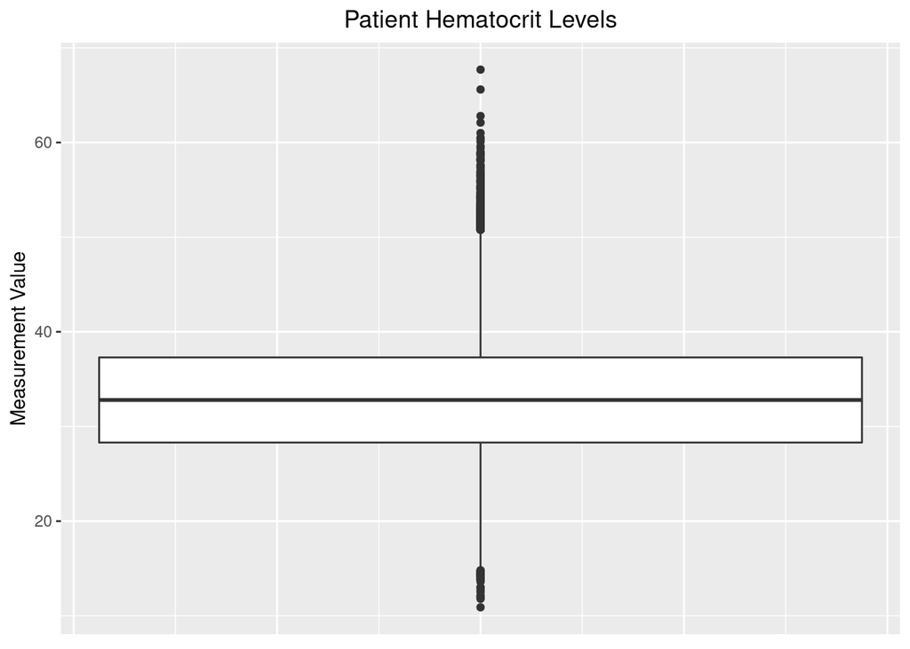

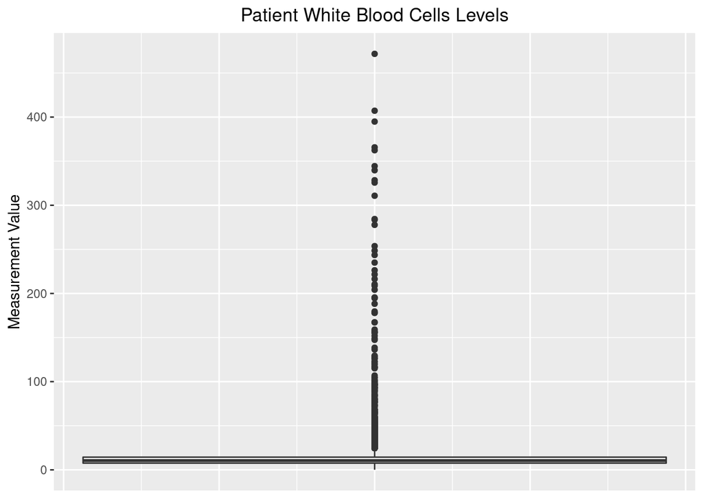

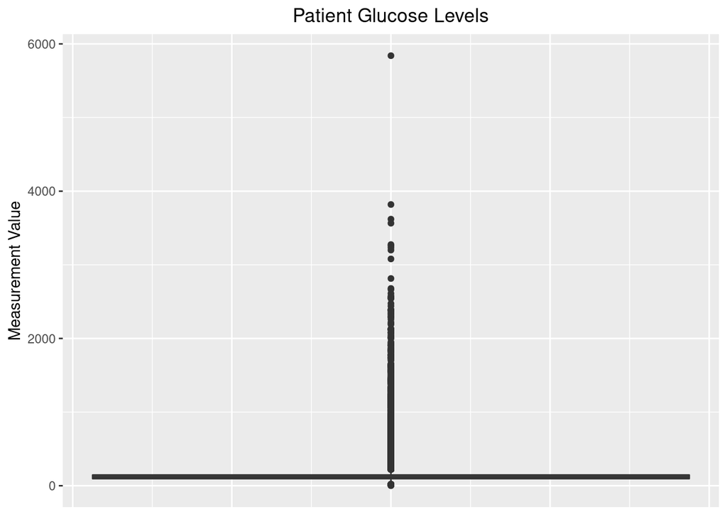

```r
# Make a boxplot for each lab measurement unfiltered
for (i in 2:11) {
  # Temporary variables needed to make plots
  name <- colnames(labevents_tble[, i])
  col <- labevents_tble[, i]
  col_vec <- labevents_tble[[i]]
  iqr <- IQR(col_vec, na.rm = TRUE)
  q1 <- quantile(col_vec, 0.25, na.rm = TRUE)
  q3 <- quantile(col_vec, 0.75, na.rm = TRUE)
  sd <- sd(col_vec, na.rm = TRUE)
  # Constructing plots inside the loop
  print(
    labevents_tble %>%
      ggplot() +
      geom_boxplot(mapping = aes(y = .data[[name]])) +
      labs(title = paste("Patient", name, "Levels"), y = "Measurement Value") +
      theme(
        plot.title = element_text(hjust = 0.5),
        axis.text.x = element_blank(),
        axis.ticks.x = element_blank()
      )
  )
}
```

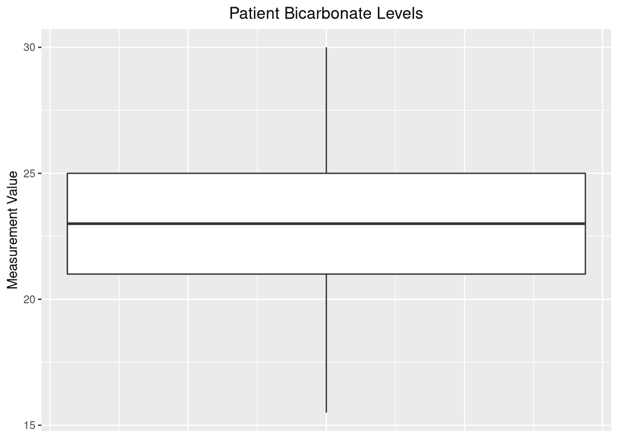

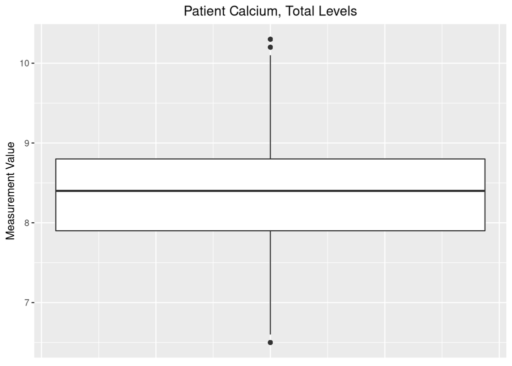

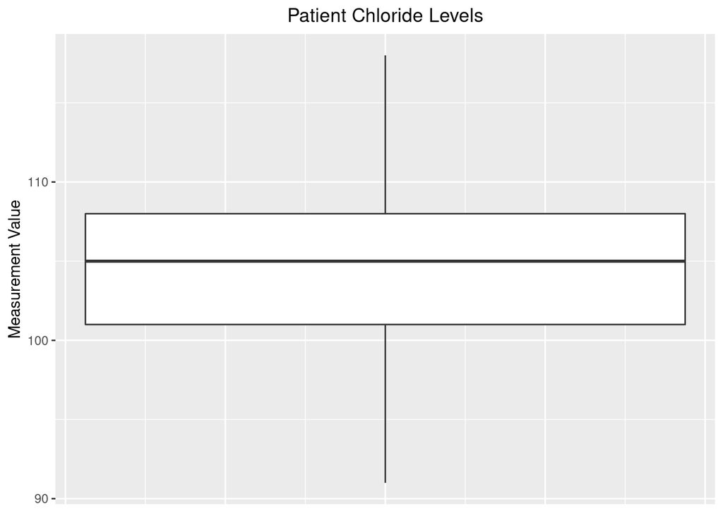

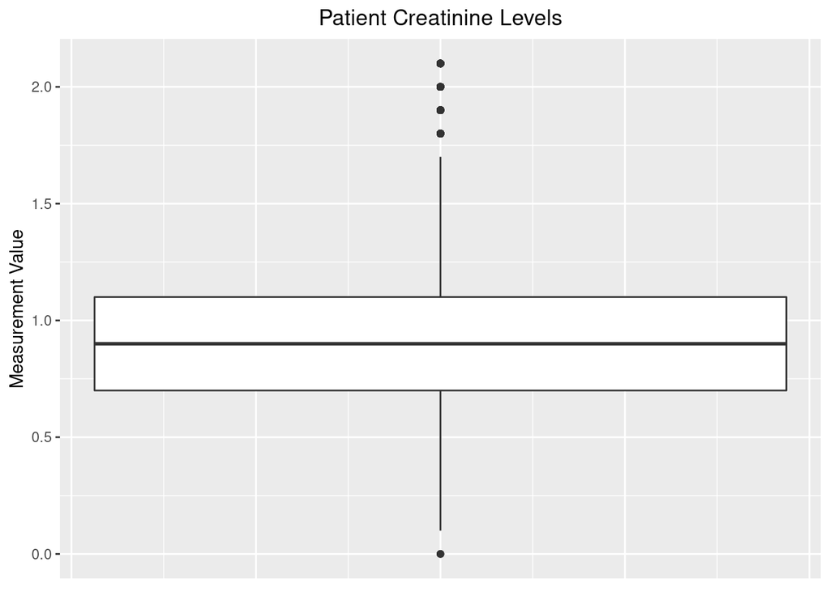

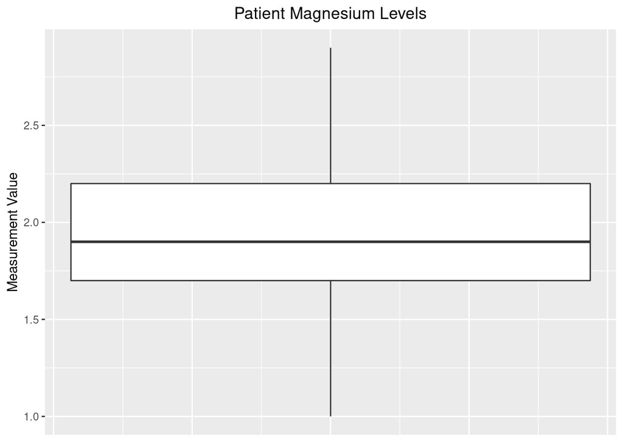

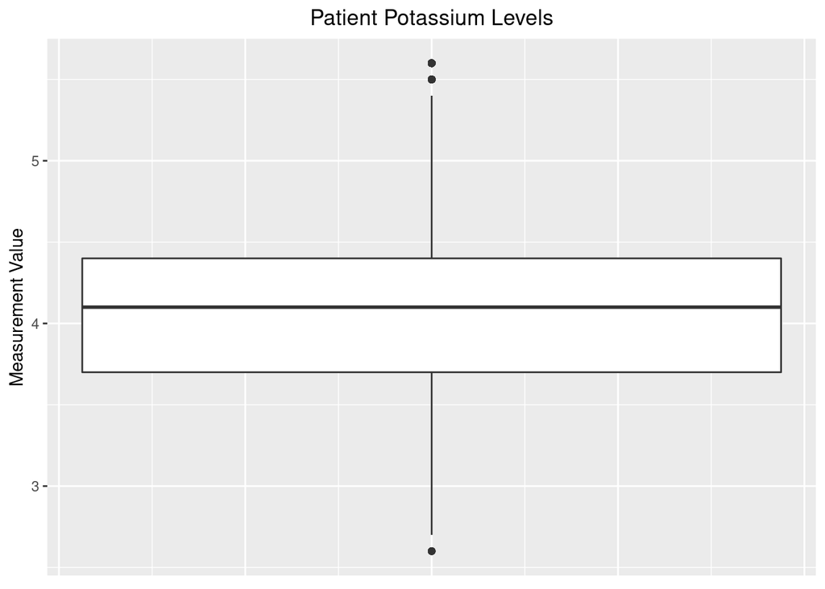

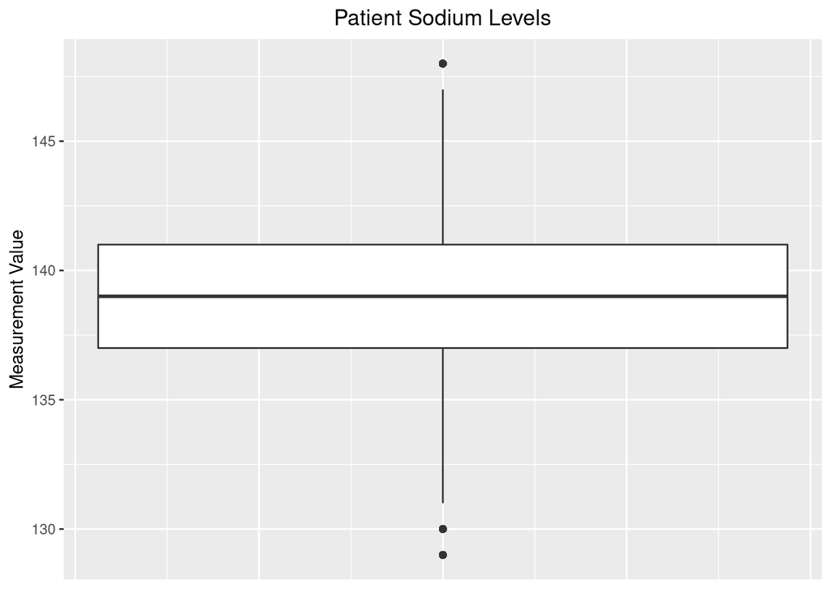

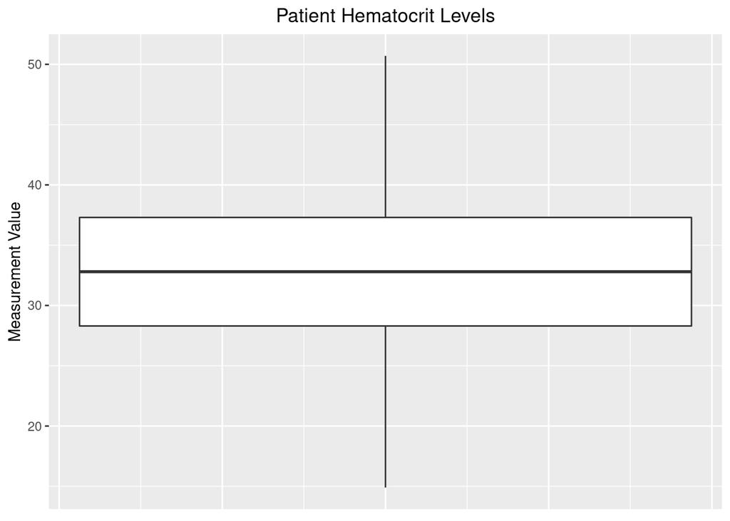

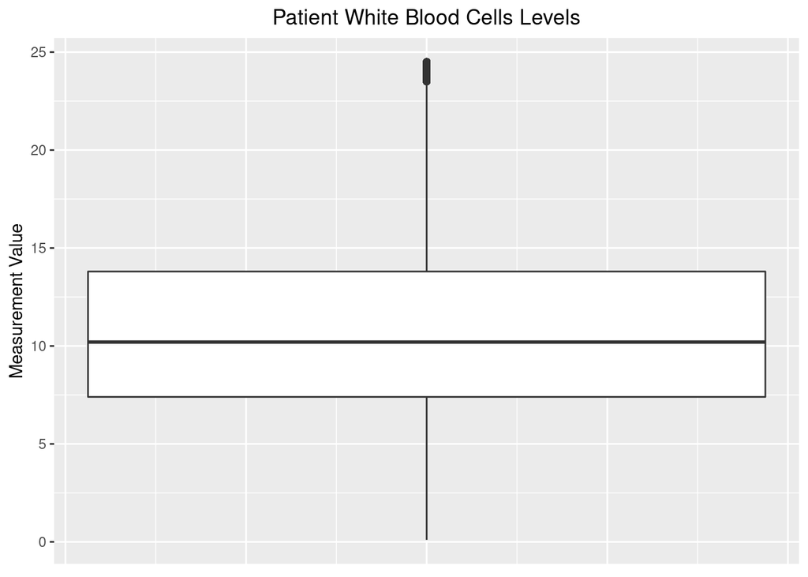

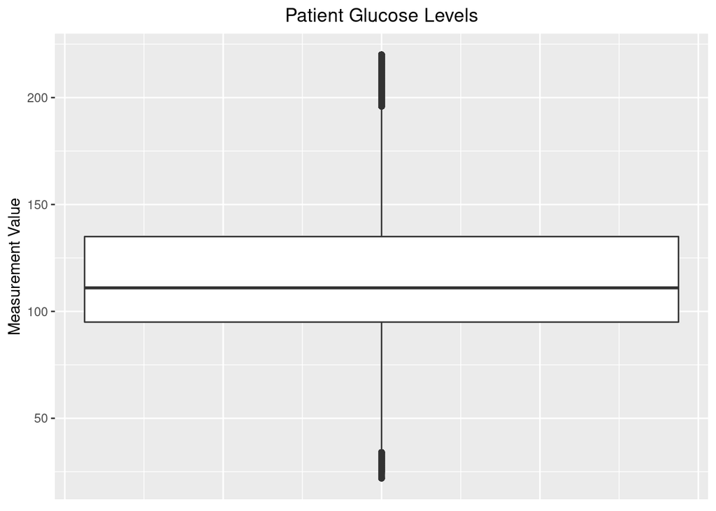

```r
# Make a boxplot for each lab measurement filtered using the 1.5 IQR rule
for (i in 2:11) {
  # Temporary variables needed to make plots
  name <- colnames(labevents_tble[, i])
  col <- labevents_tble[, i]
  col_vec <- labevents_tble[[i]]
  iqr <- IQR(col_vec, na.rm = TRUE)
  q1 <- quantile(col_vec, 0.25, na.rm = TRUE)
  q3 <- quantile(col_vec, 0.75, na.rm = TRUE)
  sd <- sd(col_vec, na.rm = TRUE)
  # Constructing plots inside the loop
  print(
    labevents_tble %>%
      filter(col < (q3 + 1.5 * iqr) & col > (q1 - 1.5 * iqr)) %>%
      ggplot() +
      geom_boxplot(mapping = aes(y = .data[[name]])) +
      labs(title = paste("Patient", name, "Levels"), y = "Measurement Value") +
      theme(
        plot.title = element_text(hjust = 0.5),
        axis.text.x = element_blank(),
        axis.ticks.x = element_blank()
      )
  )
}
```

```r
# Remove temporary variables
rm(name, col, col_vec, iqr, sd, q1, q3)
```

## Q6. Vitals from charted events

`chartevents.csv.gz` (https://mimic.mit.edu/docs/iv/modules/icu/chartevents/) contains all the charted data available for a patient. During their ICU stay, the primary repository of a patient’s information is their electronic chart. The `itemid` variable indicates a single measurement type in the database. The `value` variable is the value measured for `itemid`. The first 10 lines of `chartevents.csv.gz` are

```r
system(
  str_c(
    "zcat < ",
    shQuote(str_c(mimic_path, "/icu/chartevents.csv.gz")),
    " | head"),
  intern = TRUE
)
```

```
##  [1] "subject_id,hadm_id,stay_id,charttime,storetime,itemid,value,valuenum,valueuom,warning"
##  [2] "10003700,28623837,30600691,2165-04-24 05:10:00,2165-04-24 05:11:00,228236,0,0,,0"
##  [3] "10003700,28623837,30600691,2165-04-24 05:12:00,2165-04-24 05:14:00,225067,0,0,,0"
##  [4] "10003700,28623837,30600691,2165-04-24 05:12:00,2165-04-24 05:14:00,225070,1,1,,0"
##  [5] "10003700,28623837,30600691,2165-04-24 05:12:00,2165-04-24 05:14:00,225076,1,1,,0"
##  [6] "10003700,28623837,30600691,2165-04-24 05:12:00,2165-04-24 05:14:00,225078,1,1,,0"
##  [7] "10003700,28623837,30600691,2165-04-24 05:12:00,2165-04-24 05:14:00,225086,1,1,,0"
##  [8] "10003700,28623837,30600691,2165-04-24 05:12:00,2165-04-24 05:14:00,225091,1,1,,0"
##  [9] "10003700,28623837,30600691,2165-04-24 05:12:00,2165-04-24 05:14:00,225103,1,1,,0"
## [10] "10003700,28623837,30600691,2165-04-24 05:12:00,2165-04-24 05:14:00,225106,1,1,,0"
```

`d_items.csv.gz` (https://mimic.mit.edu/docs/iv/modules/icu/d_items/) is the dictionary for the `itemid` in `chartevents.csv.gz`.

```r
system(
  str_c(
    "zcat < ",
    shQuote(str_c(mimic_path, "/icu/d_items.csv.gz")),
    " | head"),
  intern = TRUE
)
```

```
##  [1] "itemid,label,abbreviation,linksto,category,unitname,param_type,lownormalvalue,highnormalvalue"
##  [2] "220003,ICU Admission date,ICU Admission date,datetimeevents,ADT,,Date and time,,"
##  [3] "220045,Heart Rate,HR,chartevents,Routine Vital Signs,bpm,Numeric,,"
##  [4] "220046,Heart rate Alarm - High,HR Alarm - High,chartevents,Alarms,bpm,Numeric,,"
##  [5] "220047,Heart Rate Alarm - Low,HR Alarm - Low,chartevents,Alarms,bpm,Numeric,,"
##  [6] "220048,Heart Rhythm,Heart Rhythm,chartevents,Routine Vital Signs,,Text,,"
##  [7] "220050,Arterial Blood Pressure systolic,ABPs,chartevents,Routine Vital Signs,mmHg,Numeric,90,140"
##  [8] "220051,Arterial Blood Pressure diastolic,ABPd,chartevents,Routine Vital Signs,mmHg,Numeric,60,90"
##  [9] "220052,Arterial Blood Pressure mean,ABPm,chartevents,Routine Vital Signs,mmHg,Numeric,,"
## [10] "220056,Arterial Blood Pressure Alarm - Low,ABP Alarm - Low,chartevents,Alarms,mmHg,Numeric,,"
```

1. We are interested in the vitals for ICU patients: heart rate (220045), mean non-invasive blood pressure (220181), systolic non-invasive blood pressure (220179), body temperature in Fahrenheit (223761), and respiratory rate (220210). Retrieve a subset of `chartevents.csv.gz` only containing these items for the patients in `icustays_tble` as a tibble `chartevents_tble`.

### Solution

```r
chartevents_tble <- read_csv("./icu/chartevents_filtered_itemid.csv.gz") %>%
  semi_join(icustays_tble, by = "subject_id") %>%
  print()
```

```
## # A tibble: 23,679,058 × 6
##    subject_id  hadm_id  stay_id charttime           itemid valuenum
##         <dbl>    <dbl>    <dbl> <dttm>               <dbl>    <dbl>
##  1   10003700 28623837 30600691 2165-04-24 05:28:00 220179    152
##  2   10003700 28623837 30600691 2165-04-24 05:28:00 220181    110
##  3   10003700 28623837 30600691 2165-04-24 05:30:00 220045     65
##  4   10003700 28623837 30600691 2165-04-24 05:30:00 220210     14
##  5   10003700 28623837 30600691 2165-04-24 05:38:00 223761     97.6
##  6   10003700 28623837 30600691 2165-04-24 06:00:00 220045     56
##  7   10003700 28623837 30600691 2165-04-24 06:00:00 220179    126
##  8   10003700 28623837 30600691 2165-04-24 06:00:00 220181     88
##  9   10003700 28623837 30600691 2165-04-24 06:00:00 220210     14
## 10   10003700 28623837 30600691 2165-04-24 06:09:00 220045     55
## # … with 23,679,048 more rows
```

```r
# Read in dictionary of chart measurements
 chartevents_dict <- read_csv("./icu/d_items.csv.gz")
```

2. Further restrict `chartevents_tble` to the first vital measurement during the ICU stay.

### Solution

```r
# Find first measurement after check-in and restrict chart events
chartevents_tble <- left_join(chartevents_tble, chartime) %>%
  filter(charttime >= intime) %>%
  filter(charttime <= outtime) %>%
  distinct(subject_id, itemid, .keep_all = TRUE) %>%
  arrange(subject_id) %>%
  # Create separate columns for each vital measurement and use measurement names
  inner_join(chartevents_dict, by = "itemid") %>%
  select(subject_id, label, valuenum) %>%
  pivot_wider(names_from = label, values_from = valuenum) %>%
  print(width = Inf)
```

```
## # A tibble: 53,136 × 6
##    subject_id `Temperature Fahrenheit` `Non Invasive Blood Pressure systolic`
##         <dbl>                    <dbl>                                  <dbl>
##  1   10000032                     98.7                                     84
##  2   10000980                     98                                      150
##  3   10001217                     98.5                                    151
##  4   10001725                     97.7                                     73
##  5   10001884                     98.1                                    180
##  6   10002013                     97.2                                    104
##  7   10002155                     95.9                                    126
##  8   10002223                     98.6                                    123
##  9   10002348                     97.9                                    129
## 10   10002428                    103.                                      87
##    `Non Invasive Blood Pressure mean` `Heart Rate` `Respiratory Rate`
##                                 <dbl>        <dbl>              <dbl>
##  1                                 56           91                 24
##  2                                 92           77                 23
##  3                                104           86                 18
##  4                                 59           55                 19
##  5                                 46           38                 10
##  6                                 77           80                 14
##  7                                 78           68                 18
##  8                                 80          100                 29
##  9                                 85           72                 14
## 10                                 53          124                 25
## # … with 53,126 more rows
```

3. Summarize these vital measurements by appropriate numerics and graphics.

### Solution

```r
# Summarize all vital measurements
chartevents_tble %>%
  select(-subject_id) %>%
  summarize_all(
    list(
      n_valid = ~ sum(!is.na(.)),
      mean = mean,
      sd = sd,
      median = median,
      min = min,
      max = max
    ),
    na.rm = TRUE
  ) %>%
  print(width = Inf)
```

[output not shown]

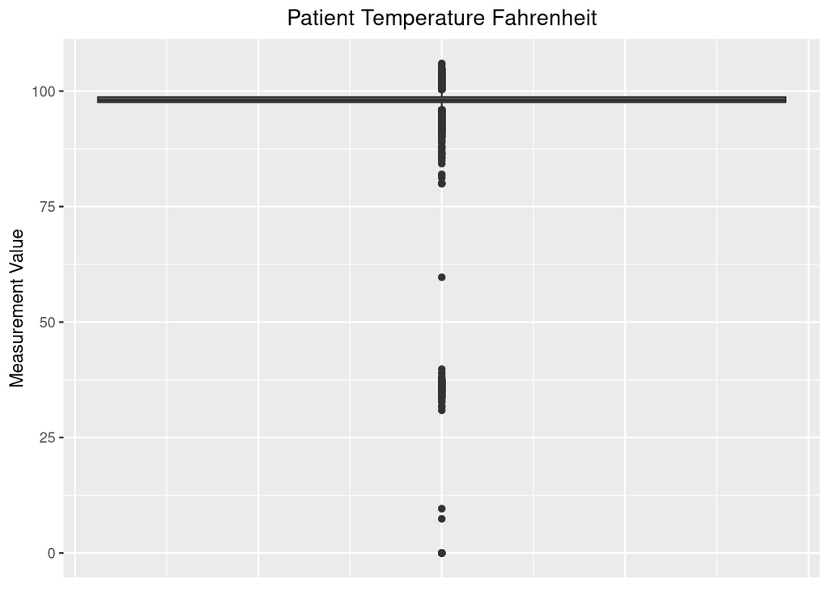

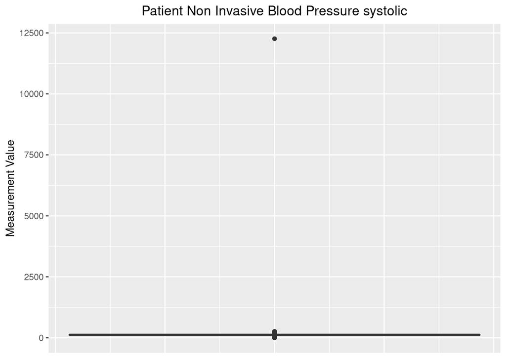

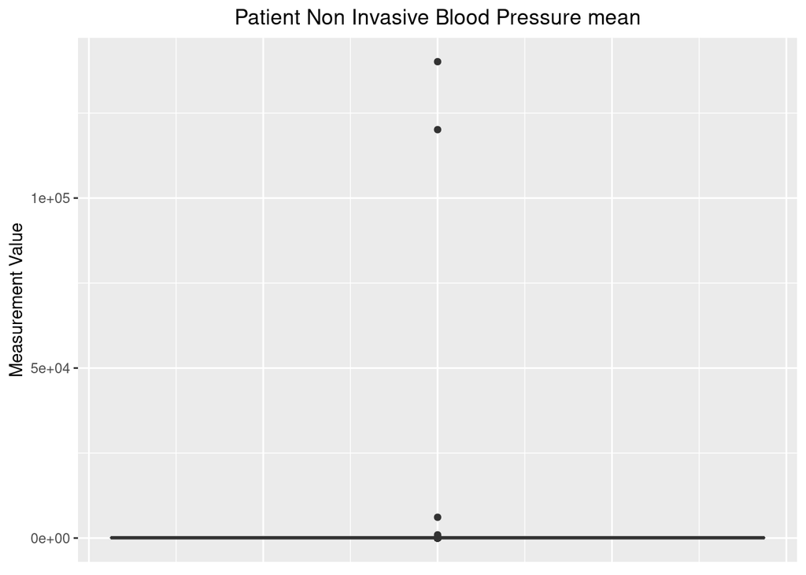

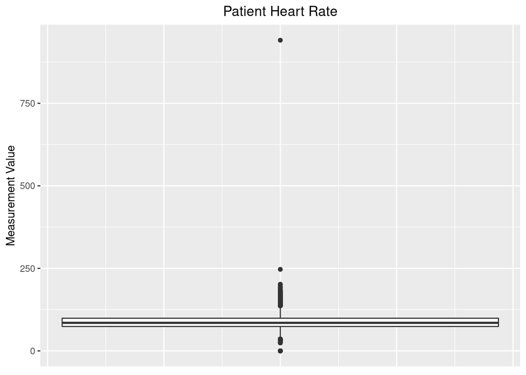

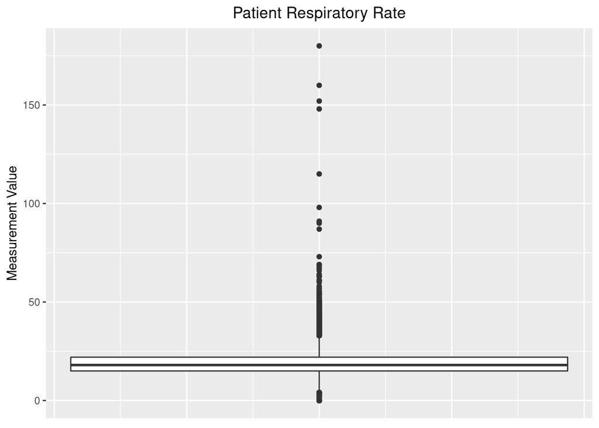

```r
# Make boxplots for vital measurements unfiltered
for (i in 2:6)
{
  # Temporary variables needed to make plots
  name <- colnames(chartevents_tble[, i])
  col <- chartevents_tble[, i]
  col_vec <- chartevents_tble[[i]]
  iqr <- IQR(col_vec, na.rm = TRUE)
  q1 <- quantile(col_vec, 0.25, na.rm = TRUE)
  q3 <- quantile(col_vec, 0.75, na.rm = TRUE)
  sd <- sd(col_vec, na.rm = TRUE)
  # Constructing plots inside the loop
  print(
    chartevents_tble %>%
      ggplot() +
      geom_boxplot(mapping = aes(y = .data[[name]])) +
      labs(title = paste("Patient", name), y = "Measurement Value") +
      theme(
        plot.title = element_text(hjust = 0.5),
        axis.text.x = element_blank(),
        axis.ticks.x = element_blank()
      )
  )
}
```

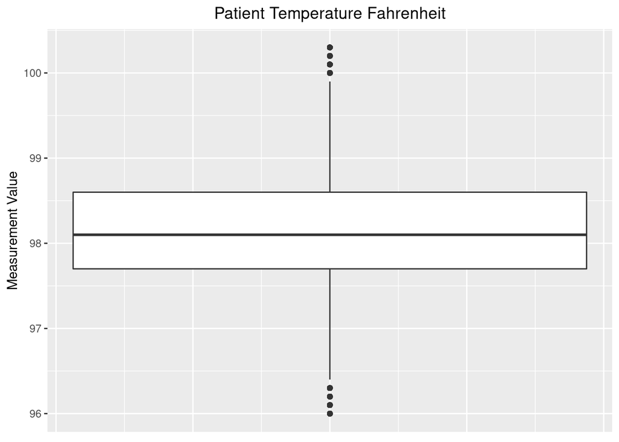

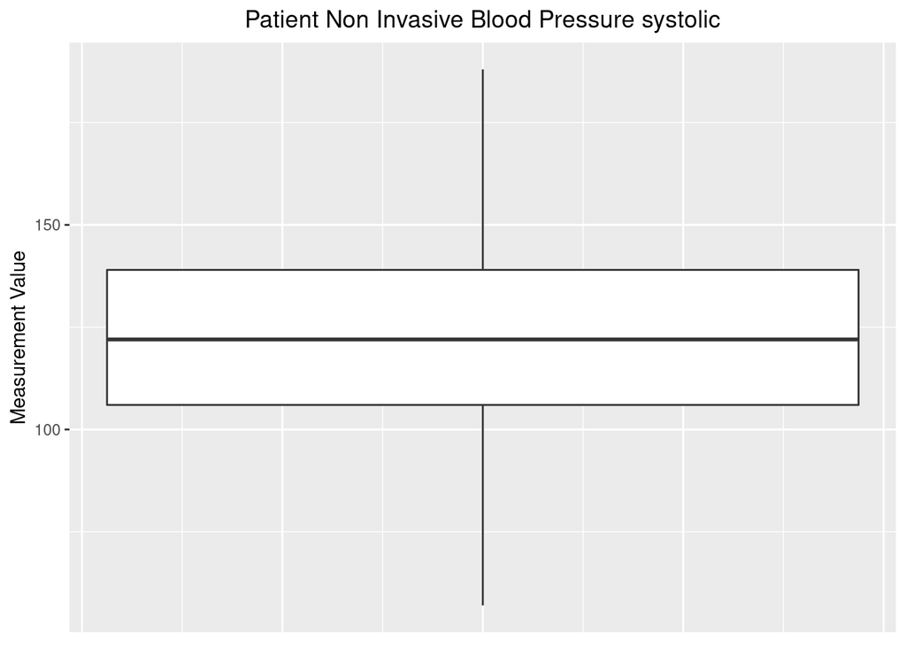

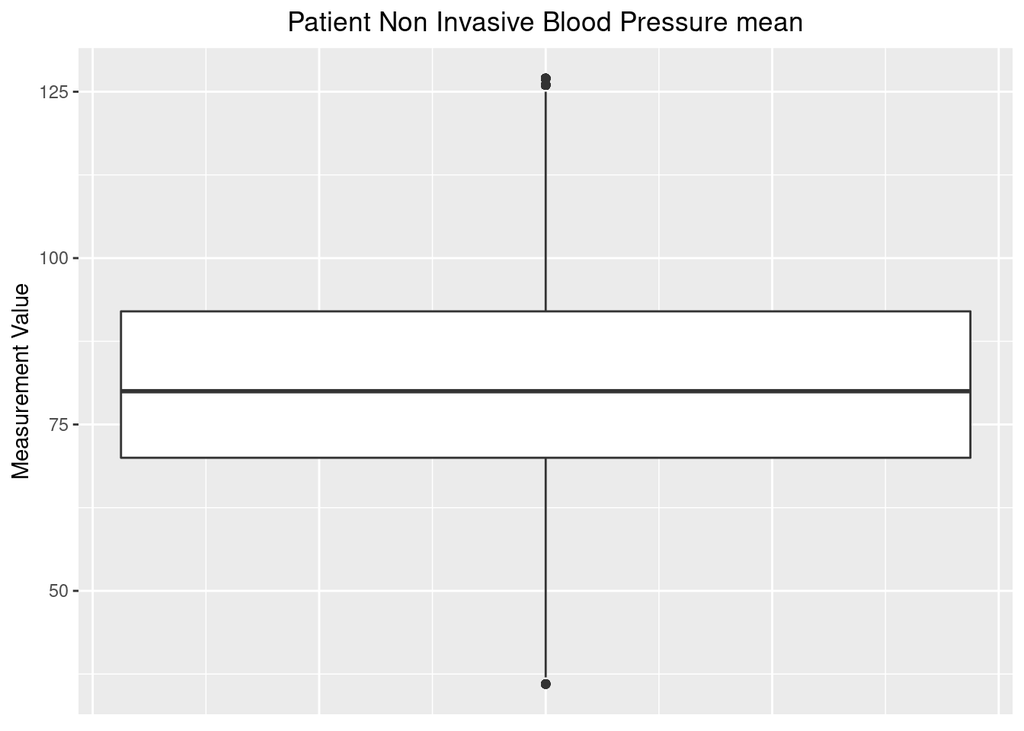

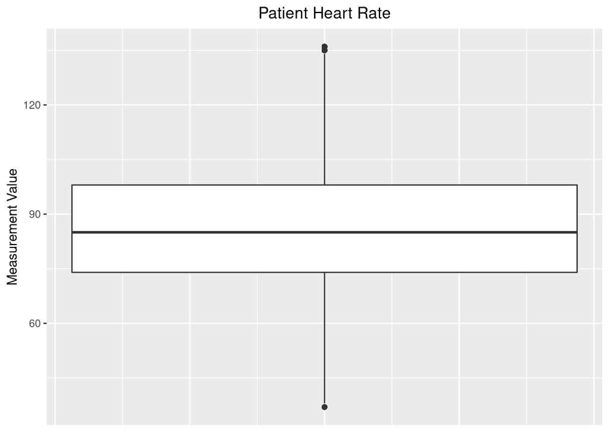

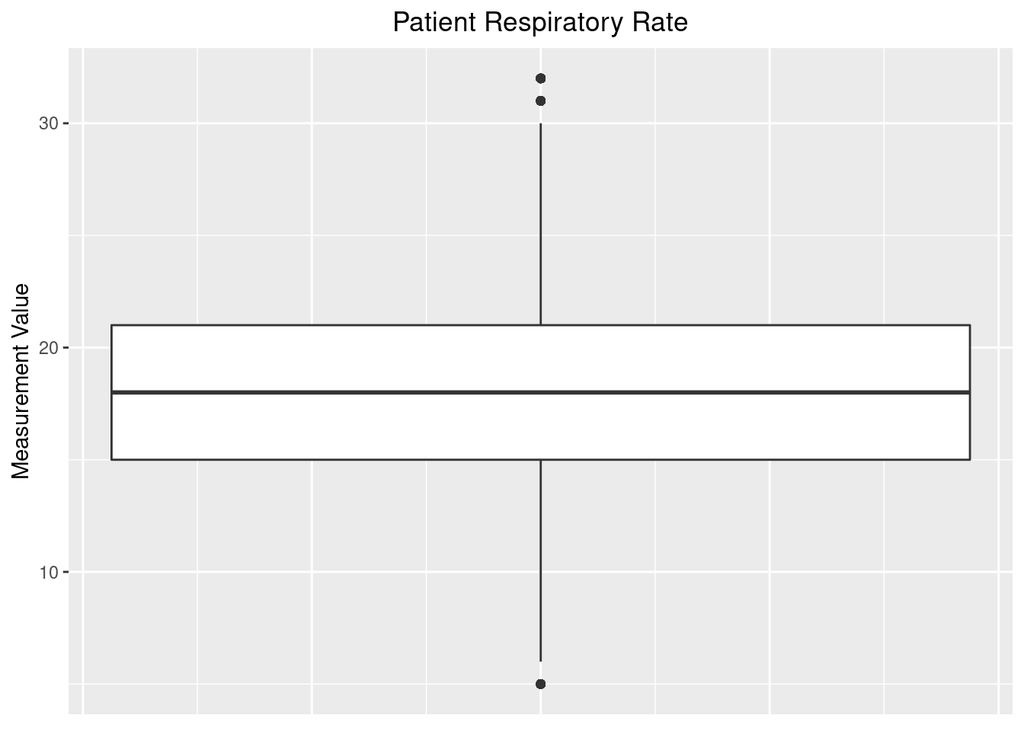

```r
# Make a boxplot for each vital measurement filtered using the 1.5 IQR rule
for (i in 2:6)
{
  # Temporary variables needed to make plots
  name <- colnames(chartevents_tble[, i])
  col <- chartevents_tble[, i]
  col_vec <- chartevents_tble[[i]]
  iqr <- IQR(col_vec, na.rm = TRUE)
  q1 <- quantile(col_vec, 0.25, na.rm = TRUE)
  q3 <- quantile(col_vec, 0.75, na.rm = TRUE)
  sd <- sd(col_vec, na.rm = TRUE)
  # Constructing plots inside the loop
  print(
    chartevents_tble %>%
      filter(col < ( q3 + 1.5 * iqr) & col > (q1 - 1.5 * iqr)) %>%
      ggplot() +
      geom_boxplot(mapping = aes(y = .data[[name]])) +
      labs(title = paste("Patient", name), y = "Measurement Value") +
      theme(
        plot.title = element_text(hjust = 0.5),
        axis.text.x = element_blank(),
        axis.ticks.x = element_blank()
      )
  )
}
```

```r
# Remove temporary variables
rm(name, col, col_vec, iqr, sd, q1, q3)
# Remove temporary table need to determine first measurements
rm(chartime)
```

## Q7. Putting things together

Let us create a tibble `mimic_icu_cohort` for all ICU stays, where rows are

- first ICU stay of each unique adult (age at admission > 18)

and columns contain at least following variables

- all variables in `icustays.csv.gz`
- all variables in `admission.csv.gz`
- all variables in `patients.csv.gz`
- first lab measurements during ICU stay
- first vital measurements during ICU stay
- an indicator variable `thirty_day_mort` whether the patient died within 30 days of hospital admission (30 day mortality)

### Solution

```r
# Create 30 day mortality variable
admissions_tble <- admissions_tble %>%
  mutate(thirty_day_mort = ifelse(deathtime - admittime < 43200, "Yes", "No"))
# Assign 30 day mortality as "No" for individuals who did not pass away
admissions_tble$thirty_day_mort[is.na(admissions_tble$thirty_day_mort)] <- "No"
mimic_icu_cohort <- admissions_tble %>%
  inner_join(icustays_tble, by = "subject_id", "hadm_id") %>%
  inner_join(patients_tble) %>%
  left_join(labevents_tble) %>%
  left_join(chartevents_tble) %>%
# Restrict age at admission > 18
  filter(year(admittime) - (anchor_year - anchor_age) > 18) %>%
  print(width = Inf)
```

```
## # A tibble: 53,065 × 43
##    subject_id hadm_id.x admittime           dischtime
##         <dbl>     <dbl> <dttm>              <dttm>
##  1   10222255  28200985 2120-11-20 20:25:00 2120-11-22 13:00:00
##  2   14485852  28712010 2113-10-31 00:23:00 2113-11-04 16:50:00
##  3   18709254  23758948 2195-10-12 01:31:00 2195-10-12 13:51:00
##  4   16837807  23526268 2151-03-19 06:09:00 2151-03-19 07:20:00
##  5   17642680  27734285 2116-05-29 12:48:00 2116-05-30 12:31:00
##  6   18230965  21251728 2142-03-12 20:00:00 2142-03-17 15:26:00
##  7   17374121  27667114 2115-07-22 07:15:00 2115-07-24 17:50:00
##  8   13346506  28533404 2181-11-19 14:32:00 2181-11-22 18:47:00
##  9   18030332  24679656 2152-07-22 21:28:00 2152-07-27 16:49:00
## 10   14328744  29576470 2126-08-20 09:26:00 2126-08-21 11:36:00
##    deathtime           admission_type     admission_location
##    <dttm>              <chr>              <chr>
```

[output cut: 119 more lines]

## Q8. Exploratory data analysis (EDA)

Summarize following information using appropriate numerics or graphs.

- `thirty_day_mort` vs demographic variables (ethnicity, language, insurance, marital_status, gender, age at hospital admission)

### Solution

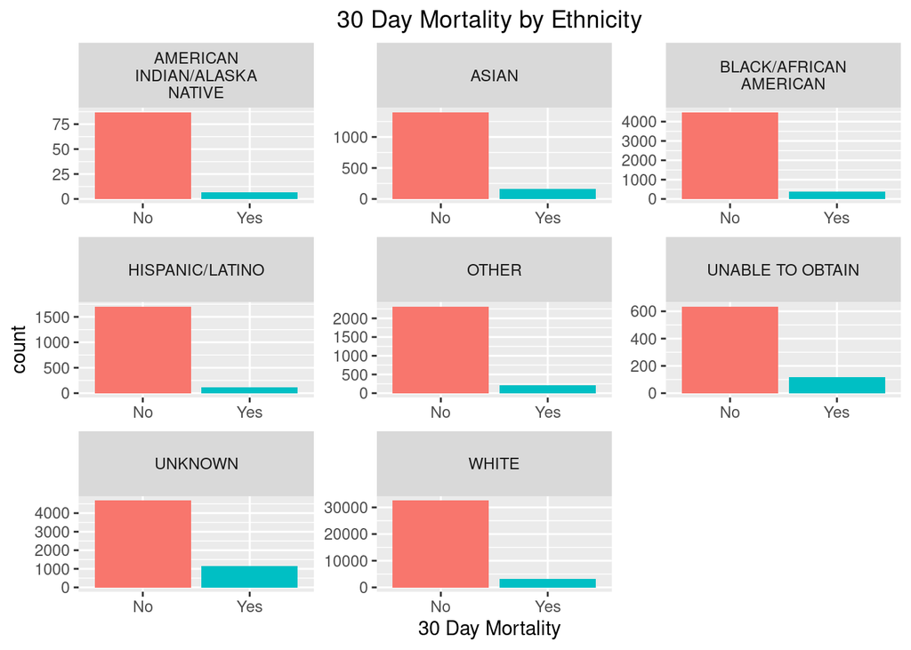

```r
# Make ethnicity chart
mimic_icu_cohort %>%
  ggplot() +
  geom_bar(mapping = aes(x = thirty_day_mort, fill = thirty_day_mort)) +
  theme(legend.position = "none") +
  labs(title = "30 Day Mortality by Ethnicity", x = "30 Day Mortality") +
  theme(plot.title = element_text(hjust = 0.5)) +
  facet_wrap(
    ~ ethnicity,
    scales = "free",
    nrow = 3,
    labeller = labeller(ethnicity = label_wrap_gen(width = 20))
  )
```

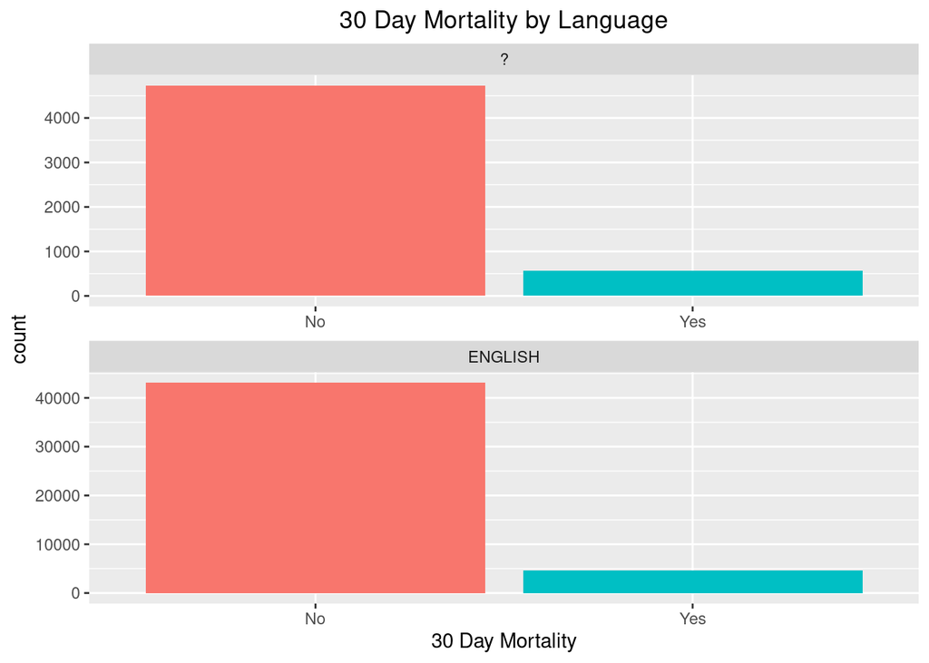

```r
# Make language chart
mimic_icu_cohort %>%
  ggplot() +
  geom_bar(mapping = aes(x = thirty_day_mort, fill = thirty_day_mort)) +
  theme(legend.position = "none") +
  labs(title = "30 Day Mortality by Language", x = "30 Day Mortality") +
  theme(plot.title = element_text(hjust = 0.5)) +
  facet_wrap(~ language, scales = "free", nrow = 2)
```

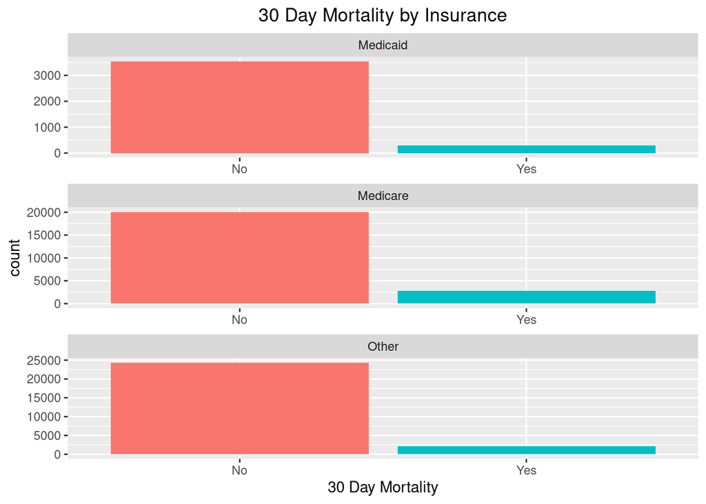

```r
# Make insurance chart
mimic_icu_cohort %>%
  ggplot() +
  geom_bar(mapping = aes(x = thirty_day_mort, fill = thirty_day_mort)) +
  theme(legend.position = "none") +
  labs(title = "30 Day Mortality by Insurance", x = "30 Day Mortality") +
  theme(plot.title = element_text(hjust = 0.5)) +
  facet_wrap(~ insurance, scales = "free", nrow = 3)
```

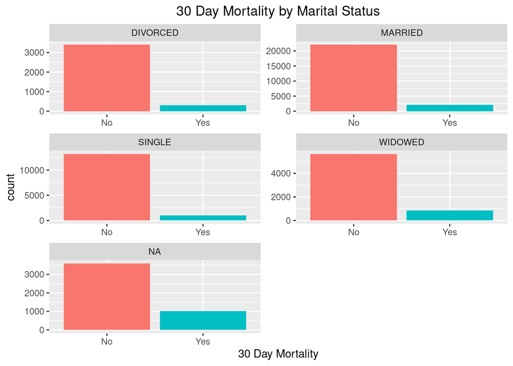

```r
# Make maritial status chart
mimic_icu_cohort %>%
  ggplot() +
  geom_bar(mapping = aes(x = thirty_day_mort, fill = thirty_day_mort)) +
  theme(legend.position = "none") +
  labs(title = "30 Day Mortality by Marital Status", x = "30 Day Mortality") +
  theme(plot.title = element_text(hjust = 0.5)) +
  facet_wrap(~ marital_status, scales = "free", nrow = 3)
```

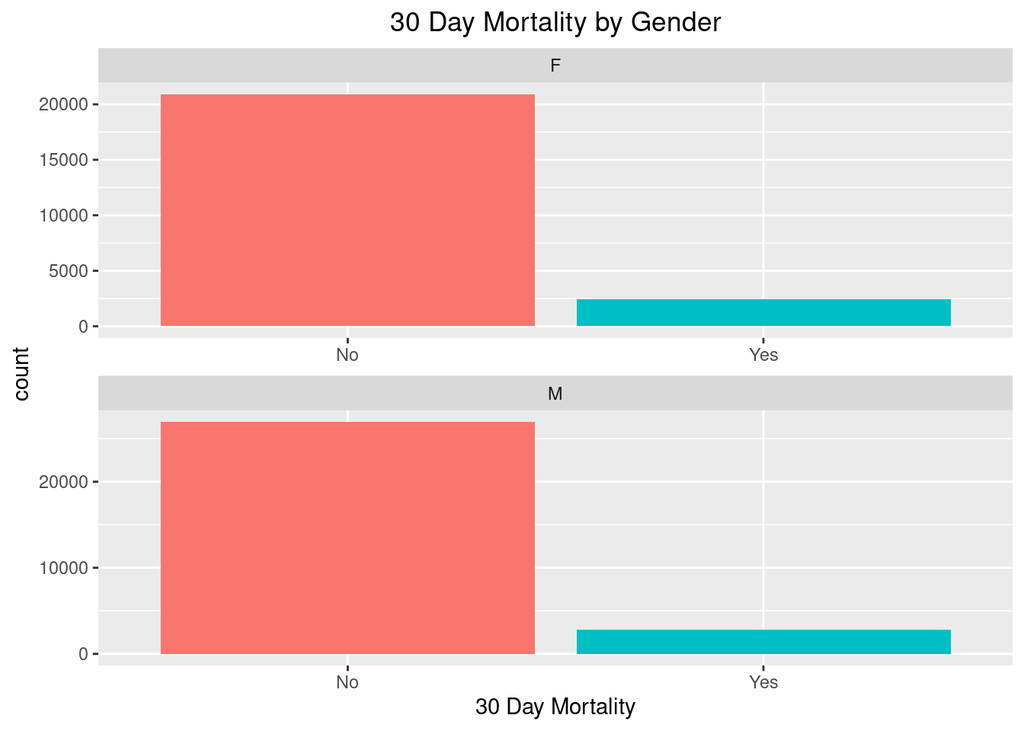

```r
# Make gender chart
mimic_icu_cohort %>%
  ggplot() +
  geom_bar(mapping = aes(x = thirty_day_mort, fill = thirty_day_mort)) +
  theme(legend.position = "none") +
  labs(title = "30 Day Mortality by Gender", x = "30 Day Mortality") +
  theme(plot.title = element_text(hjust = 0.5)) +
  facet_wrap(~ gender, scales = "free", nrow = 2)
```

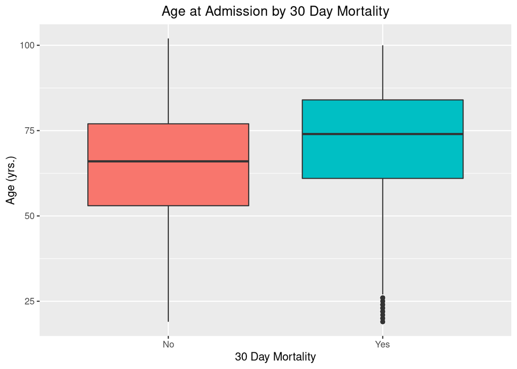

```r
# Make age at admission plot
mimic_icu_cohort %>%
  mutate(age = (year(admittime) - (anchor_year - anchor_age))) %>%
  ggplot() +
  geom_boxplot(
    mapping = aes(
    x = thirty_day_mort,
    y = age,
    fill = thirty_day_mort)
  ) +
  theme(legend.position = "none") +
  labs(
    title = "Age at Admission by 30 Day Mortality",
    y = "Age (yrs.)",
    x = "30 Day Mortality"
  ) +
  theme(plot.title = element_text(hjust = 0.5))
```

- `thirty_day_mort` vs first lab measurements

### Solution

```r
mimic_icu_cohort %>%
  group_by(thirty_day_mort) %>%
  select(16, 29:38) %>%
  summarize_all(
    list(
      n_valid = ~ sum(!is.na(.)),
      mean = mean,
      sd = sd,
      median = median,
      min = min,
      max = max
    ),
    na.rm = TRUE
  ) %>%
  print(width = Inf)
```

```
## # A tibble: 2 × 61
##   thirty_day_mort Bicarbonate_n_valid `Calcium, Total_n_valid` Chloride_n_valid
##   <chr>                         <int>                    <int>            <int>
## 1 No                            47563                    46452            47570
## 2 Yes                            4795                     4780             4806
##   Creatinine_n_valid Magnesium_n_valid Potassium_n_valid Sodium_n_valid
##                <int>             <int>             <int>          <int>
## 1              47587             47434             47567          47569
## 2               4801              4783              4807           4809
##   Hematocrit_n_valid `White Blood Cells_n_valid` Glucose_n_valid
##                <int>                       <int>           <int>
## 1              47574                       47562           47456
## 2               4796                        4787            4792
##   Bicarbonate_mean `Calcium, Total_mean` Chloride_mean Creatinine_mean
##              <dbl>                 <dbl>         <dbl>           <dbl>
## 1             23.4                  8.39          105.            1.26
## 2             21.2                  8.24          103.            1.77
##   Magnesium_mean Potassium_mean Sodium_mean Hematocrit_mean
##            <dbl>          <dbl>       <dbl>           <dbl>
## 1           2.00           4.13        139.            33.0
## 2           2.03           4.29        139.            32.6
##   `White Blood Cells_mean` Glucose_mean Bicarbonate_sd `Calcium, Total_sd`
##                      <dbl>        <dbl>          <dbl>               <dbl>
## 1                     11.7         145.           3.84               0.760
## 2                     15.2         174.           5.36               1.17
##   Chloride_sd Creatinine_sd Magnesium_sd Potassium_sd Sodium_sd Hematocrit_sd
##         <dbl>         <dbl>        <dbl>        <dbl>     <dbl>         <dbl>
## 1        5.85          1.41        0.414        0.571      4.12          6.30
## 2        7.50          1.53        0.450        0.773      6.00          7.14
##   `White Blood Cells_sd` Glucose_sd Bicarbonate_median `Calcium, Total_median`
##                    <dbl>      <dbl>              <dbl>                   <dbl>
## 1                   8.87       149.                 23                     8.4
## 2                  16.0        145.                 21                     8.2
##   Chloride_median Creatinine_median Magnesium_median Potassium_median
##             <dbl>             <dbl>            <dbl>            <dbl>
## 1             105               0.9                2              4.1
## 2             104               1.3                2              4.2
##   Sodium_median Hematocrit_median `White Blood Cells_median` Glucose_median
##           <dbl>             <dbl>                      <dbl>          <dbl>
## 1           139              32.8                       10.3            113
## 2           139              32.1                       12.6            139
##   Bicarbonate_min `Calcium, Total_min` Chloride_min Creatinine_min Magnesium_min
##             <dbl>                <dbl>        <dbl>          <dbl>         <dbl>
## 1               7                  5.3           80            0             1
## 2               3                  1.8           77            0.1           0.6
##   Potassium_min Sodium_min Hematocrit_min `White Blood Cells_min` Glucose_min
##           <dbl>      <dbl>          <dbl>                   <dbl>       <dbl>
## 1           2.4        112           11.9                     0.1           1
## 2           1.6         97           10.9                     0.1          10
##   Bicarbonate_max `Calcium, Total_max` Chloride_max Creatinine_max Magnesium_max
##             <dbl>                <dbl>        <dbl>          <dbl>         <dbl>
## 1              46                   13          132           33.1           9.2
## 2              45                   43          140           23.1           8.1
##   Potassium_max Sodium_max Hematocrit_max `White Blood Cells_max` Glucose_max
##           <dbl>      <dbl>          <dbl>                   <dbl>       <dbl>
## 1           9.9        169           67.7                    407.        5840
## 2           9.4        176           62.1                    472.        3260
```

### Solution

- `thirty_day_mort` vs first vital measurements

```r
mimic_icu_cohort %>%
  group_by(thirty_day_mort) %>%
  select(16, 39:43) %>%
  summarize_all(
    list(
      n = ~ sum(!is.na(.)),
      mean = mean,
      sd = sd,
      median = median,
      min = min,
      max = max
    ),
    na.rm = TRUE
  ) %>%
  print(width = Inf)
```

```
## # A tibble: 2 × 31
##   thirty_day_mort `Temperature Fahrenheit_n`
##   <chr>                                <int>
## 1 No                                   47499
## 2 Yes                                   4747
##   `Non Invasive Blood Pressure systolic_n` `Non Invasive Blood Pressure mean_n`
##                                      <int>                                <int>
## 1                                    47592                                47569
## 2                                     4961                                 4963
##   `Heart Rate_n` `Respiratory Rate_n` `Temperature Fahrenheit_mean`
##            <int>                <int>                         <dbl>
## 1          47854                47824                          98.1
## 2           5210                 5204                          97.5
##   `Non Invasive Blood Pressure systolic_mean`
##                                         <dbl>
## 1                                        124.
## 2                                        122.
##   `Non Invasive Blood Pressure mean_mean` `Heart Rate_mean`
##                                     <dbl>             <dbl>
## 1                                    85.2              86.8
## 2                                   109.               93.2
##   `Respiratory Rate_mean` `Temperature Fahrenheit_sd`
##                     <dbl>                       <dbl>
## 1                    18.4                        2.96
## 2                    21.1                        5.93
##   `Non Invasive Blood Pressure systolic_sd`
##                                       <dbl>
## 1                                      24.0
## 2                                     175.
##   `Non Invasive Blood Pressure mean_sd` `Heart Rate_sd` `Respiratory Rate_sd`
##                                   <dbl>           <dbl>                 <dbl>
## 1                                  551.            19.8                  6.08
## 2                                 1988.            22.4                  6.82
##   `Temperature Fahrenheit_median` `Non Invasive Blood Pressure systolic_median`
##                             <dbl>                                         <dbl>
## 1                            98.2                                           122
## 2                            98                                             117
##   `Non Invasive Blood Pressure mean_median` `Heart Rate_median`
##                                       <dbl>               <dbl>
## 1                                        81                  84
## 2                                        78                  92
##   `Respiratory Rate_median` `Temperature Fahrenheit_min`
##                       <dbl>                        <dbl>
## 1                        18                            0
## 2                        20                            0
##   `Non Invasive Blood Pressure systolic_min`
##                                        <dbl>
## 1                                          0
## 2                                          9
##   `Non Invasive Blood Pressure mean_min` `Heart Rate_min` `Respiratory Rate_min`
##                                    <dbl>            <dbl>                  <dbl>
## 1                                      0                0                      0
## 2                                     19                0                      0
##   `Temperature Fahrenheit_max` `Non Invasive Blood Pressure systolic_max`
##                          <dbl>                                      <dbl>
## 1                         106                                         259
## 2                         106.                                      12262
##   `Non Invasive Blood Pressure mean_max` `Heart Rate_max` `Respiratory Rate_max`
##                                    <dbl>            <dbl>                  <dbl>
## 1                                 120130              941                    180
## 2                                 140119              182                    115
```

- `thirty_day_mort` vs first ICU unit

### Solution

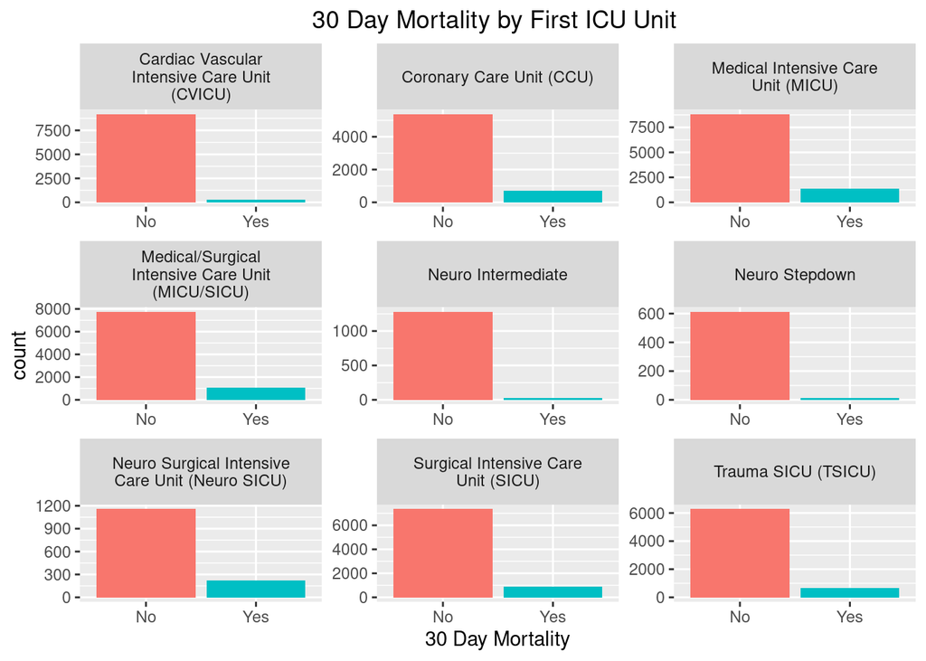

```r
mimic_icu_cohort %>%
  ggplot() +
  geom_bar(mapping = aes(x = thirty_day_mort, fill = thirty_day_mort)) +
  theme(legend.position = "none") +
  labs(title = "30 Day Mortality by First ICU Unit ", x = "30 Day Mortality") +
  theme(plot.title = element_text(hjust = 0.5)) +
  facet_wrap(
    ~ first_careunit,
    scales = "free",
    nrow = 3,
    labeller = labeller(first_careunit = label_wrap_gen(width = 25))
  )
```